Gale Academic OneFile

# The scarlet legacy: the British Army's forgotten presence in Moreton Bay, 1860-69

## Citation metadata

Authors: [Jeff Hopkins-Weise](https://go-gale-com.ezproxy.une.edu.au/ps/advancedSearch.do?method=doSearch&searchType=AdvancedSearchForm&userGroupName=dixson&inputFieldNames[0]=AU&prodId=AONE&inputFieldValues[0]=%22Jeff+Hopkins-Weise%22) and [Rod Pratt](https://go-gale-com.ezproxy.une.edu.au/ps/advancedSearch.do?method=doSearch&searchType=AdvancedSearchForm&userGroupName=dixson&inputFieldNames[0]=AU&prodId=AONE&inputFieldValues[0]=%22Rod+Pratt%22)

Date: June 2001

From: Sabretache(Vol. 42, Issue 2)

Publisher: Military Historical Society of Australia

Document Type: Article

Length: 20,044 words

## Main content

Full Text:

The role of British soldiers in the newly formed colony of Queensland in the decade of the 1860s was quite unlike their former service in the penal station of Moreton Bay from 1824 to 1842. Not only had convict transportation to the eastern Australian Colonies ceased, and as a consequence the penal station became a free settlement, but the post-Crimean British Army itself had evolved into a more professional and humane organisation. Furthermore, with the cessation of transportation and the increasing cost of garrisoning a global empire with a thinly distributed British Army came the realisation in Britain that those colonies which possessed self-government should also take on the responsibility, at least in part for their own defence. (3) It is by comparing the role of British military detachments at Moreton Bay during its penal operation to its emergence as a colonial metropolis in the 1860s that we can see that the despised red-coated gaolers became the honoured representatives of Empire and an integral aspect of colonial society. This is not to say that the British soldier in early Queensland entirely escaped the onerous duty of guarding criminals, although a clear distinction needs to be made between the `convict' as a product of an imperial policy of transportation up to 1840 and the `prisoner' who was a colonial civil offender in the 1860s; a distinction to which contemporaries were very much alive to. Thus within the period of transportation to free settlement at Moreton Bay there is not only a transfer of authority from a military to a civil administration, but also an increasing acceptance that these soldiers were becoming more a part of colonial society rather than remaining apart from it. With this change of role (and status) the British soldier was not only defender and gaoler, but his scarlet-coat would serve as a reminder within Britain's the far-flung corners of empire that the `imperial sentiment' which Governor George Ferguson Bowen so fervently fostered, (4) would be a visible and tangible reassurance to colonists, a nucleus upon which local volunteer forces could be raised and the foundation of Bowen's gubernatorial authority as Queensland's first governor. (5)

Despite this being a geographically specific case study, its implications for continuing investigations into the role of the British Army (and Navy) throughout the Australian and New Zealand Colonies are far reaching and enduring. Sadly, this history largely remains to be explored by either Australian, New Zealand, and for that matter, British, military historians. Therefore it is hoped that in undertaking this study we may stimulate not only greater awareness of this neglected field of study, but also encourage others to commence related research into the various Imperial garrisons stationed throughout these Colonies during the late eighteenth and much of the nineteenth centuries.

The British Army in Australasia

The units of the British Army and Royal Navy which served in the Australasian Colonies (6) during the nineteenth century represented the moral and physical presence of Empire situated in the distant south-west Pacific region. The presence of `redcoats' and `jack tars' as the day-to-day Imperial representatives provided a sense of security and strength often beyond their actual numbers on station or in garrison. On this, Peter Burroughs, in a review of imperial defence and the Victorian Army expressed:

```
   Except possibly in India, ... garrisons throughout the empire were too
   sparse and thinly spread to overawe local populations. Often their presence
   did no more than betoken a power held in reserve, ready to be summoned when
   necessary; in this respect the threat of force was as potent as its actual
   employment, a form of imperial bluff that masked considerable weaknesses
   and vulnerability. (7)
```

Burroughs' argument that the Empire was held together by this `Imperial bluff' is particularly evident in the Australasian context. Despite their numbers being limited at times, the presence of Imperial soldiers or sailors nonetheless were constant reminders for the public of each Colony's inclusion within a greater coalition of colonies and territories that made up the powerful British Empire -- the Colony of Queensland was no exception. The small elements of the 12th (East Suffolk) Regiment of Foot (1860/61-66), followed by the 50th (Queen's Own) Regiment of Foot (1866-69), and including the Royal Marines at Somerset, Cape York (1864-67), providing that sense of Empire and place in colonial Queensland.

In relation to the presence of the British Army in Australasia, Burroughs also directed attention to the neglected topic of `the impact of British military garrisons on colonial economies and societies'. From review of the available Empire historiography, Burroughs was able to state that this has revealed

```
   ... our knowledge is extremely sketchy [on the impact of the British
   military], yet British spending on wars of conquest and pacification,
   military works and permanent garrisons must at times have constituted large
   injections of capital into relatively small communities, have shaped their
   operations through commissariat spending and manipulation of rates of
   exchange, and have made fortunes for some local contractors and
   merchants....

   Almost equally virgin territory is the impact of British military garrisons
   on colonial societies.... (8)
```

Similarly as occurred in Moreton Bay, contracts for the Imperial Commissariat were very significant in the convict period but by the 1860s this was rivalled by the `informal' contributions of soldiers themselves working day jobs as civilians. This occurrence was prevalent amongst the soldiers of the 12th Regiment in Brisbane, for which their commanding officer, Lieutenant D T Seymour, turned a blind eye. However, soldiers themselves had very little disposable income of their own.

Another purpose for Army or Empire research is to re-incorporate the experience of the British military garrisons and navy stationed in Australia, their involvement in, and the impact of the New Zealand wars of the 1840s and 1860s, back into Australian historiography. This still remains to be effectively carried out with regard to Australia's frontier conflict where the British Army played a significant role from initial European settlement until the 1840s, and was also a body from which personnel for the Mounted Police were procured from the 1820s until 1850. This of course is quite apart from the role and place of former soldiers in sailors as part of this experience. Amongst writers of Australian military history especially there has been a common misnomer to ignore or avoid the role and place of the British soldiers and sailors from the history of colonial Australia. Often this has occurred (and still occurs) because of the `blinkered' approach of seeing such military personnel as British only and not Australian, and therefore able to be left out of the historiographical picture. This somewhat jaundiced perspective is particularly evident in the historiographic treatment of the rise of various Australasian colonial forces. Many histories convey the impression that such voluntary forces sprang forth ex nihilo fully trained, uniformed and accoutred without the benefit of any regular military instructors or indeed any model upon which to base such a force. Indeed, upon surveying the histories so far written on the local volunteer forces of the Australian colonies, one might be forgiven for assuming that such corps were the product of spontaneous generation, since scant, if any reference is made either to those British regulars who instructed these volunteers and frequently composed their commissioned and non-commissioned ranks. (9) Such perspectives are not only forgetful, but are disparaging to the many dedicated professional British soldiers who laid the foundation for what has become today the Australian Defence Force.

As a result of these omissions a significant aspect of the history of the British Army in Australasia has received little or no recognition. That is the recruitment of colonials -- some Australian born, others immigrants to, but residents of these colonies, into the British line regiments in garrison in Australia. In this way these largely unrecognised `Australian' colonials also went on to serve in New Zealand during the 1860s. The 40th Regiment garrisoned in Melbourne especially, but also the 12th Regiment in Sydney, enlisted, or recruited for men to bring regimental numbers up to strength from the late 1850s into the 1860s. (10) Other members of the British Army serving in Australasia were Australian born but appear to have enlisted in Great Britain or other locales within the Empire while others had prior British military service enrolled in the colonial volunteer forces thus adding their professionalism and expertise to this spontaneous voluntary movement. (11) Many of these men may well have been sons, some orphaned, of British soldiers who had garrisoned these Colonies in earlier periods. An 1864 obituary for a young officer of the 70th Regiment, Captain D M Fraser, who saw service in New Zealand, reveals not only Australian birth, but also a family connection via his mother who was from Parramatta, New South Wales, who had married an officer of the 80th Regiment. (12) The 80th Regiment had been in garrison in Australia (including detachments at Moreton Bay between August 1839 to May 1842 and New Zealand 1836-44) before departing Sydney for duty in India where it was soon on active service during the Sutlej Campaign of 184546. (13) This particular family lost their father and husband during the battle of Ferozeshuhur (21-22 December 1845), revealing in the process the path into the military that orphaned sons often found themselves, in this case via a deceased father's regiment. (14)

While it is apparent that many such men were to see service in the New Zealand wars of the 1860s, evidence for similar Australian connected individuals in the 1840s is not as clear. Between 1829 and 1846 enlistment in the British Army was theoretically for life, though after fifteen years service a free discharge could be procured, or else discharge on medical grounds. Soldiers with less that the requisite fifteen years service could only obtain their discharge by purchase (20 [pounds sterling]), though the sum involved required many years of savings or money from relatives or friends. (15) Changes in 1847 in the form of the Limited Enlistment Act saw the maximum term of service in the infantry set at ten years, with provisions for re-enlistment permitted for an additional eleven years. (16) Heaton in 1879 stated that recruiting for the British Army first commenced in New South Wales on 1 April 1839, but more recent research has revealed Australian born or enlisted personnel joined units of the British Army as early as the 1800s. (17) Review of monthly strength returns of the British Army in Australia allowed Maurice Austin to point out: `it is apparent commencing with the New South Wales Corps (102nd Regiment), that a steady trickle of local recruits flowed into all British garrison regiments until the last, the 18th, left Australia in 1870.' (18)

Despite the start made by the late Brigadier Maurice Austin, few detailed studies of the role and experience of Regiments in Australasia have emerged revealing evidence of the importance of the social and economic interaction of the British Army and colonial Australasians, nor the significant numbers of Australian born or enlisted men within regiments. This in itself sheds light on the failings of much of the history written about the colonial history of Australasia. For Australia the impact of the Anzac legend has dominated the thinking and writing of this nation's military history, compounded by the myth of the peaceful settlement of Australia, has dealt a deathly silence towards the service of the British Army and Navy in this country.

One aspect rarely noted or analysed is to ascertain the presence, significance, and contributions of personnel who had been former British officers, non-commissioned officers or men within not only the Queensland Volunteer movement, but as prevalent within the ranks the Police, Prison or other civil services. In both Australia and New Zealand, most Volunteers Units had a small cadre of retired or discharged Military personnel who provided the experience, enthusiasm, and military structure around which colonial units were formed, trained and operated. In the Australian context, one of the few historians to draw attention to this phenomenon has been Peter Stanley in his `Heritage of Strangers'. In discussing the impact of such former or seconded British personnel upon the development of the Australian Colonial Volunteers, Stanley pointed out:

```
   ... The colonial volunteer forces were not established in emulation of the
   red-coated regular regiments which they supplemented and later replaced,
   but, rather, on the model of the British rifle volunteers, whose character
   and motivation was altogether different from those of the infantry of the
   line. The regulars drew on men who were supposed to have no option but to
   enlist, who served and fought under rigid unthinking discipline....
   Colonial Troops, respectable men, serving voluntarily and finding
   restrictive discipline and rigid tactics unnecessary, nevertheless still
   needed military skills, and called upon former regulars to provide both
   commissioned and non-commissioned direction....

   Of equal importance to shaping the military force ... may have been the
   non-commissioned officers and warrant officers who joined colonial forces
   after their retirement from the British Army. Other British NCOs sought or
   accepted secondment to the colonial forces, often becoming officers, and in
   the meantime enjoying a prosperity and standard of living to which few
   could have aspired after discharge in Britain. (19)
```

Of course records detailing a soldier's discharge in a location such as New Zealand does not always mean such former soldiers stayed in that Colony as settlers. Numbers of the soldiers of the 12th and 40th Regiments who took their discharge in New Zealand quickly departed that Colony to return to the Australian Colonies. This was undertaken because of the belief of better opportunities, to return to family or friends, or job offers made while part of the garrison forces before their departure for New Zealand service. These return cross-Tasman travellers are examples of the `inter-colonial fluidity' that existed throughout the 19th century, and are indicative of a greater experience of, and willingness by individuals and families to travel from colony to colony in search of better economic and social conditions. (20) Such discharged personnel therefore maintained long-term social and economic connections and contribution in Australia, as did the many who remained in New Zealand, long after their war service had terminated. (21) In relation to former members of Queensland's small 12th Regiment detachment who departed Brisbane for New Zealand service in late 1866, at least eight men who had served with the Queensland Detachment of the 12th took their discharge in early 1867 just prior to the Regiment's departure for England. (22) Of these, two -- Patrick Clancy (23) and Daniel Cahill (24) -- are confirmed as returning to Queensland shortly after obtaining their discharges. Further substantial evidence of the presence of such ex-British military personnel in Queensland colonial society can be found in the voluminous ledgers of the Imperial Pensions Registers detailing hundreds of such people (and not only men) frequently holding positions of responsibility and all contributing to the colony's economy. (25)

The British Army in Queensland, 1859-66: the 12th Regiment Experience

With the withdrawal of Ensign George Arnold Cameron's detachment of the 11th Regiment from Brisbane in July 1850, the infant settlement was for the first time since its creation without any military force. (26) This was the source of much consternation and petitioning by local inhabitants to have such a force restored. (27) Governor Bowen, immediately prior to his assuming office as Queensland's first governor almost a decade later was fully in accord with this view albeit for different reasons. In his correspondence to the Duke of Newcastle, who then administered the Colonial Office, Bowen had requested in August 1859 a full company of regular soldiers. (28) Though this request was readily acceded to, numerous obstacles arose to prevent its fulfilment for within the complex system of regimental rotations, inter-colonial rivalry, and hostilities breaking out in New Zealand, it would be another seven years before this company of regulars eventually arrived in Brisbane. Although Bowen had been authorised to raise a local volunteer force, on the model of spontaneous national voluntaryism that was then sweeping Britain, he personally held such local forces in low regard. Quite apart from Bowen's conviction that a handful of redcoated regulars would bolster the sentimental bonds of Empire in the isolated colonial metropolis, he also held an abiding distrust of any locally raised force as being `politically partial'. (29) Bowen felt such a force would not remain aloof from the sway of local politics, as would a force of British regulars. There were other reasons for Bowen's preference for British regulars as well. He felt it his personal right as a colonial governor to have such a force loyal to his position and authority. Apart from this there was the necessity of having professional instructors and British regulars to form a `nucleus' upon which any local force would be trained and would rally around in time of crisis. (30) Again, Bowen held little faith in local volunteers who could not be depended upon in an emergency. However, due to the inadequacy of troop strengths in Western Australia, elements of the 12th Regiment could not be spared for their return to New South Wales, which Colony would then be enabled to supply the requested company of regulars for Brisbane. (31) Although before all this could take place, events in New Zealand required every available British soldier the Australian colonies could spare. This did not prevent Bowen from continuing a stream of correspondence with both the Colonial Office and the Commanding Officer of British Forces, Major-General Sir Thomas Pratt, imploring that only a few dozen soldiers might be spared to assist in training a local volunteer force.

By September 1860 a temporary compromise was reached in providing a well qualified drill and musketry instructor in the person of Colour-Sergeant William Green of the 12th Regiment whose `pleasing and winning manner is calculated to secure the esteem, as well as respect of those under his tuition'. (32) In April 1863 Green was replaced by Sergeant Thomas D P Hawkes of the same regiment and continued his tireless efforts to revive a flagging volunteer movement which, through a variety of causes almost ceased to exist until renewed hostilities in New Zealand during 1868-69 revived the movement. In January of 1861 the first detachment of the 12th Regiment under the command of Lt David Seymour arrived in Brisbane and quickly established a reputation for drunken rowdiness and desertion. (33) The presence of these soldiers was not merely to bolster imperial sentiment and train volunteers. There was also the harsh economic reality that under the Queensland Military Contribution Act of 1864, the cost of the entire Brisbane detachment of the 12th Regiment was still less than the annual wages of four constables employed at the colonial government's expense. (34) Even though the War Office had declared that such British troops were not to be used as substitutes for constables or gaolers, this stricture was disregarded in view of the money saved by an impoverished colonial treasury.

Due to the relatively small size of the Brisbane 12th Regiment detachment, combined with their multiplicity of duties such as providing guards for prisoners, the Treasury and the Military Barracks (both in William Street and later from 1864 at Petrie Terrace), left little interaction with the early Queensland Volunteer movement. The exception being the provision of a single instructor and parties to clean the guns of the Volunteer Artillery who whether due to a lack of skill or motivation appear to have left this menial task to their regular comrades in arms. (35) Another aspect notable with the detachment of the 12th Regiment at Brisbane was its relatively high level of desertion which accounted for almost one in five of all those soldiers of the 12th posted here. The reasons for this are not difficult to discover since the Brisbane Courier contained frequent complaints from disgruntled workers who noted that soldiers, after their morning parade, would don civilian attire and put in a day's work in Brisbane before retiring in the evening back to their barracks. Although these were frequently referred to as `deserters' (and undoubtedly some were), the majority were more guilty of the lesser offence of being absent without leave by supplementing their meagre military pay in a labour hungry colonial metropolis. Commanding Officer of the detachment, Lieutenant David Seymour who was in the invidious position of also being Police Commissioner was singled out as negligent in preventing this practice particularly since many of these soldiers were `working as mechanics at a much lower rate of pay'. (36) In an anonymous retort which, judging by the intimate knowledge of military and police duties suggests it may have been penned by Lieutenant Seymour himself, this claim was weakly rebuffed by denying that any soldiers were engaged in such a practice and that, even if they were, it was more the responsibility of the police to arrest such offenders than it was of the commanding officer to ensure that it didn't happen in the first instance. (37) It is more likely that those soldiers who did indeed intend to desert travelled westward to the Darling Downs to seek labour and anonymity rather than run the risk of detection in Brisbane and there exist examples of such soldiers being apprehended at locations such as Ipswich and Dalby. (38)

The interaction of members of Brisbane's 12th Regiment detachment with colonial society, although not as pervasive as their successors of the 50th Regiment were later to be, was still significant for laying the foundations upon which the latter detachment substantially built upon. The rise of the Queensland Rifle Association in May 1861, intended as it was to emulate the newly formed British National Rifle Association, was locally patronised by such notables as Sir Maurice Charles O'Connell, Captain H D Pitt, RA, as well as Governor Bowen himself. (39) This Association was intended to compliment the early Volunteer movement with which it became synonymous and to inculcate a martial spirit among Brisbane's citizenry. Ultimately it shared the same waning interest the Volunteer movement laboured under until events in New Zealand generated a revival of matters military. `Prize shoots' were arranged for various shooting matches arranged within the Volunteers, or in competition with soldiers of the 12th Regiment for purses of money, National Rifle Association medals, or coveted `prize rifles' such as the newly invented Terry & Calisher's capping breech-loader. (40) This generated a brief interest in shooting matches in the early 1860s for which the 12th Regiment's detachment demonstrated considerable marksmanship, even though their target practice did result in the death of one wandering cow and narrowly missing a very fortunate pelican when a soldier's bullet lodged into a post in Russell street, South Brisbane. (41)

Brisbane's detachment of the 12th Regiment also officiated at formal functions in conjunction with elements of the Volunteer units at levees and the opening of parliament where they provided a guard of honour for His Excellency's entourage. On a few instances, this force drilled alongside members of the Brisbane company of the Volunteer Rifles; a practice that became more common with the arrival of the 50th Regiment in October 1866. Although the presence of the 12th Regiment in Brisbane was more ceremonial or ornamental than practical, there were occasions when their roles were more active. These included providing guards for prisoners in Brisbane prior to the use of the Proserpine as a prison hulk or the establishment of the penal station on St Helena Island in Moreton Bay. (42) Of greater note were the demands made upon the detachment of the 12th during the Brisbane Riots (which in fact extended far beyond Brisbane) in September 1866. While the Brisbane Courier recorded public thanks for the role of the Queensland Volunteer Artillery in promptly turning out in full strength during this civil unrest, it was less effuse in admitting that the small detachment of the 12th Regiment had actually provided a guard for Parliament House for '84 hours without rest' during the period of the disturbance. (43) This was almost the last activity involving the detachment of the 12th since the following month in October they were replaced by the long awaited company of the 50th Regiment direct from New Zealand. (44) Sergeant Thomas Hawkes, who had succeeded Colour-Sergeant William Green was granted a testimonial dinner in recognition of his services to the local Volunteer movement and the detachment itself was publicly feted on its departure as having `conducted themselves in a manner so creditable to them'. (45)

The Place of Former British Army or Honourable East India Company Servicemen in Colonial Queensland

The role of individuals with prior service in the British Army (or Navy) and Honourable East India Company was certainly significant to the growth of the Volunteer movement, quite apart from members of the detachments of the 12th and 50th Regiments posted to Brisbane. Among those with such prior service who went on to serve in the Queensland Volunteer Rifles were such notables as Major Edward Lewis Burrowes late of the 97th Regiment. Burrowes was appointed Deputy Surveyor General of Queensland and was also gazetted a 1st Lieutenant in the Brisbane Troop of the Queensland Mounted Rifles. (46) Likewise, Francis Robert Chester Master, who had commanded the detachment of the 58th Regiment stationed at Brisbane briefly between November 1844 and January 1845 before serving in the New Zealand conflict of the 1840s. (47) Master sold his commission in the 58th Regiment upon his return from New Zealand and bought `Mangoola' at Warwick in 1854. His hospitality was remarked upon in Oscar de Satge's Pages from the journal of a Queensland squatter and he became a noted local celebrity. Indeed, with the initial raising of the Queensland Volunteer Rifles, Master offered his services as an officer although this met with some difficulty. (48) Master went on to contribute to the formation of the Queensland Rifle Association as well as the framing of its rules and regulations. Similarly, Colonel Charles Gray, sometimes termed the `father of Ipswich' was also instrumental in the formation of Queensland's first volunteer corps at Ipswich. (49) Gray had served at the battle of Waterloo in the elite 95th Rifle Regiment as Aide-decamp to Major-General Johnstone and had been earlier wounded at the siege of Badajoz during the Peninsular Campaign. On 26 May 1860 he was gazetted Captain of the Ipswich Company of the Queensland Volunteer Rifle Brigade and was active in this and the Queensland Rifle Association until the Volunteer movement in Queensland waned to such an extent that his commission, along with many other officers, was cancelled.

Another notable, more for his political than military contribution was Charles Lilley whose entry to military life was less than conspicuous. He had enlisted on 3 December 1851 as a private in the prestigious 1st Dragoon Guards and began preaching to his comrades upon industrial reform and temperance before going absent without leave, which earned him the displeasure of his officers as well as a twenty-eight day solitary cell punishment. (50) In this respect his brief military career paralleled that of Richard Cobden who was also described as an educated agitator although by February 1854 Lilley decided military life did not agree with him and so purchased his discharge for 30 [pounds sterling]. However his service with the Queensland Volunteer Forces won him greater esteem with his contemporaries. With the formation of the Spring Hill and Fortitude Valley Volunteer Rifle Corps (later known as No. 3 Company, QVRB) in June 1867, Lilley was elected Captain and was also on the Queensland Rifle Association's committee of management until his resignation on 23 May 1868. So popular was Lilley with his corps that he was presented with a handsome framed testimonial by these Volunteers. Ultimately, Lilley's contribution to the Queensland Volunteer movement was to be the most enduring since after many redesignations this corps survived as the 9th Battalion.

Although Governor George Bowen is credited with the impetus for forming Queensland's Volunteer Forces, efforts to create such a body predate Bowen's arrival. John Kent, a resident of Ipswich had in July 1839 replaced George Thom as Deputy Assistant Commissary General at Brisbane and by August 1859 proposed the formation of a North Australian Rifle Club to `act as light troops for defence'. (51) Although this request met with no immediate response, it was not long before Queensland's first volunteer corps was formed under the designation number 1 Company Queensland Rifle Brigade with John Kent appointed as its 1st Lieutenant on 23 May 1860. Kent's predecessor, George Thom had been a sergeant in the 4th Regiment when it was despatched for convict guard duties to New South Wales in 1835. Thorn was a veteran of both the battle of Albuera and Waterloo and was instrumental in the formation of the Ipswich Volunteers, forming a member of the recruiting committee. The service of William Martin Boyce with the Queensland Volunteers is an interesting one since Boyce, along with another notable, Louis Hope, had enlisted with the Honourable East India Company (HEIC) which was quite distinct from the British Army even though personnel were frequently shared, (52) In the years immediately following the Indian Mutiny in 1857, many officers and men were unwilling to continue their military service as part of the British Army and such dissatisfaction eventually escalated into what has been described as the `White Mutiny'. (53) Many officers took the opportunity of taking their discharge and Governor Bowen, although initially reluctant at the prospect of accepting a soldier-settlement scheme for ex-Indian Army officers and men, eventually acquiesced. In this way Queensland, due to its climate, was promoted as an ideal place of retirement for those taking their discharge from the HEIC or accepting an out-pension in the Colony. Boyce may have been one of the many who came to Queensland under this scheme, which certainly benefited the Queensland Volunteer Force and was instrumental at its inception and that of the para-military Queensland Rifle Association. Boyce was immediately gazetted as Queensland Volunteer Force secretary and Quarter-Master with the rank of 1st lieutenant with number 2 Company of the Queensland Volunteer Rifles. However, by 1863 with the rapid deterioration of the Queensland Volunteer movement and the disbanding of most units, the office of Quartermaster was abolished and with it Boyce's commission.

It is apparent from such biographical cameos that many ex-British Army or HEIC personnel served with, or were involved in the formation of the Queensland Volunteer Forces. Their roles were quite significant as officers, NCOs and instructors and hence imparted their training and professional knowledge to the newly formed Queensland Volunteers Force. How many other ex-British soldiers formed the ranks as Volunteer privates is difficult to quantify although by examining the lists of those receiving British Army out-pensions it is possible to identify many names. (54) Names such as James Warner (late 15th Dragoons), John Walsh (late 38th Regt), David McFarlane (late 42nd `Black Watch' Regt), James Dignam (late 48th Regt) and Edward Deshon (late 68th Regt) (55) who briefly put the volunteers through a `course of musketry', all contributed to the development of Queensland Volunteer Force. (56)

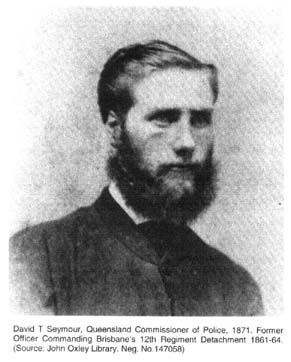

The service of ex-Indian Army officers gave a `flavour' to Queensland's colonial society which is most apparent in the style of architecture they brought with them. The familiar high-set homes with deep set verandahs, wide windows and a central corridor allowing the free flow of cool air had been a feature of British India for which Queensland's climate was quite comparable. There is a sense of isolated camaraderie apparent among such `Old Indians' who took up land in Queensland; glimpses of which appear in Robert Gray's Reminiscences of India and North Queensland. While looking for suitable country to settle he found a lonely hut near Herberton, `on looking into one of the huts on the afternoon of our arrival, I saw a man lying on one of the bunks fast asleep, quite unconscious of the flies which were -- well, fairly busy. His face seemed familiar, and on his waking up I found that he was Stewart of the 79th [Regt], whom I had last seen in the Immaum Bara at Lucknow'. Similarly, while Gray and his wife were visiting Charters Towers, they encountered the Dickens family. `Charles Short Dicken, who had been a lieutenant in the 87th [Regt], and whom I had not seen since the early `sixties' was present as well as `an old friend whom I had known as a captain in the 75th [Regt] in India. The Rev C M Pym having left the army, had been ordained.' (57) An examination of the Queensland Imperial Pension Register for the period 1872-99 indicates that there were thirty-four other ex-service personnel who had served in either the army or navy in India whilst members of the HEIC and, after 1857, the Queen's Regiments stationed there. (58)

Many more ex-soldiers who had served with their regimental detachments at Brisbane evidently enjoyed their posting and returned to settle in the district upon their discharge. Apart from Sergeants Brady (59) and Pike (60) of the 50th Regiment, many other soldiers returned to settle at their earlier posting such as Privates Joseph Tristram, William Kilner and Thomas Walker of the 12th Regiment who nominated Brisbane as their place of residence. (61) However, among the greatest contributors to colonial Queensland's development were from men who had served in the British Army and used their administrative skills in the service of the New South Wales and later Queensland Governments. These ex-soldiers were evident from the very beginning of the Moreton Bay penal settlement and continued to the close of the century. Among the first of these was Private Charles Fraser, late of the 48th Regiment, who accompanied Colonial Botanist and explorer Allan Cunningham on his expeditions as he earlier had with John Oxley in 1817. (62) The arrival of Cunningham and Fraser at Moreton Bay on 5 June 1828 is noted in a passenger manifest necessary for any vessel proceeding to the penal settlement of Moreton Bay. Fraser had originally enlisted in the 56th Regiment at Perth, Scotland on 8 June 1815, when he gave his occupation as gardener. (63) Certainly Fraser's gardening skill must have been extraordinary to be appointed Colonial Botanist by Governor Lachlan Macquarie in January 1821. At the time of Macquarie's retirement and Sir Thomas Brisbane's appointment as Governor of New South Wales in December 1821, Macquarie recommended Fraser to Sir Thomas Brisbane's `patronage, protection and kindness'. At the time of Fraser's arrival at Brisbane, William Whyte, an officer late of the 57th Regiment who had arrived in August 1829, as assistant to the Superintendent of Agriculture, and later as clerk in the Commandant's (Clunie's) office until 1842. (64) During this time, in 1838, Andrew Petrie was appointed Superintendent of Works at Moreton Bay and was attached to the Royal Engineers posted to Sydney under the Commanding Royal Engineer, Colonel George Barney. Petrie was a trained civil engineer whose achievements are well recorded elsewhere. (65)

One of the most influential personalities at Moreton Bay at the time of the district's opening to free settlement, in February 1842, was Dr Stephen Simpson, Commissioner of Crown Land. According to one biographer who quotes from Henry Smart Russell's Genesis of Queensland, Simpson had served in the 14th Light Dragoons during the war against Napoleon. (66) However, Russell makes no reference to Simpson's military service other than to say that he `had been attached to a crack cavalry corps in the old war' mentioning nothing of the 14th Light Dragoons specifically. (67) Furthermore, an examination of the official Army Lists between 1790 and 1830 do not mention him as a serving officer although the possibility exists that he may have served in a non-commissioned rank. Nevertheless, it is evident from an examination of his journal that Simpson was quite familiar with light cavalry tactics and recommended such a force be raised to protect squatters in his district. In a report to Governor George Gipps dated 5 January 1844, Simpson complained of the inefficiency of the Mounted Police assigned to him and proposed instead the formation `of the lightest irregular cavalry, whereas we are equipped [Mounted Police] as the heaviest Dragoons'. (68) Clearly Simpson had more than a passing acquaintance with the usage of light cavalry whether he served as an officer in the 14th Light Dragoons or not.

Other positions of civil responsibility were also assumed by ex-military officers such as Philip Doyne Vigors of the 11th Regiment, who also undertook extensive instruction in engineering having mastered `surveying, levelling, the use of instruments, plotting, mapping and a fair course of mathematics'? His credentials as a skilled engineer won him considerable praise from his instructors. According to Nehemiah Bartley he was appointed as Surveyor of Roads at Moreton Bay in 1855 and, despite his credentials, was criticised for his levelling of the road between Brisbane and Ipswich. Bartley recalled that,

```
   He had been an Army lieutenant, a fact which, in early Australian days,
   seemed to be held sufficient qualification for a man to fill any office
   outside of the church. He was appointed Superintendent of roads for Moreton
   Bay, and set to work to clear the road between Brisbane and Ipswich. But,
   in place of stumping and clearing the trees off in the old orthodox
   fashion, he put men on with crosscut saws to shave the trees down at the
   level of the earth, and the ungrateful bushmen, who used the road, used to
   complain that in wet weather these wooden `tables' were more slippery than
   a wood pavement to a galloping horse, besides tripping him up as the earth
   washed away from the edge of the stump. The experiment was not a success,
   as the trees soon grew up again, and a bit of straight road near Ipswich,
   got up in this fashion, was known, long afterwards, as `Virger's Avenue'.
   He was, of course, known by the witty young ladies of the period as `Poor,
   dear Virger.' (70)
```

By February 1856 Vigors had been offered the position of Adjutant within his original regiment, the 11th, a position `which I am desirous of accepting' and so forwarded his resignation to Governor Sir William Thomas Denison. (71)

Captain William Irving, late of the 28th Regiment, was one of the few Waterloo veterans who chose to settle in the Moreton Bay district. Irving is rarely mentioned as a settler in the district although he did gain some attention as an expert witness in the trial of some soldiers of the 11th Regiment at Brisbane who had been charged with manslaughter in 1849 in `The Affray at Yorks Hollow'. (72) Captain Francis Durrell Vignoles also of the 28th Regiment was another settler who became owner of Western Creek station on the Darling Downs. Vignoles had initially purchased a 32 perch block of land at Ipswich for 8 [pounds sterling] 16s in June 1849 before taking up Western Creek where his grave remains. All those who knew him described him in affectionate terms. (73)

Similarly, there exist references to other retired military officers having settled in the district although their presence is known only in a passing phrase from the Brisbane Courier. In describing a levee called by Governor Bowen in honour of the Queen's birthday, a few officers, retired in the district, were invited such as Captain H D Sullivan late of the 13th Light infantry and Captain J E D MacCarthy late of the 40th Regiment. (74) Another officer, Lieutenant D C Mitchell, late of the Dumfries Militia, in a letter to the editor of the Brisbane Courier, described his astonishment at the lack of esprit de corps among the `young men of Brisbane' in allowing the Queensland Light Horse to be disbanded through lack of interest. Mitchell in response proposed the formation of a Yeomanry corps composed of `fifty young gentlemen'. (75)

More intriguing were the numbers of non-commissioned ranks who, upon taking their discharge settled near Brisbane to take employment or perhaps serve in the local Volunteers. Undoubtedly they were well represented within this force with their prior rank usually resulting in their appointment within the Volunteers, at the same (or higher) rank during the corps formation in 1860. However, due to the high inter-colonial mobility of these men it has not been possible to identify those among the ranks of the Volunteers who had served in the Army from those who had not. If the number of ex-British Army Volunteer officers is, in any way proportionate to the number of ex-regulars who served in the Volunteer ranks, it would also seem that their number might be significant.

Even long after the last of the Imperial regiments left the Australian colonies in 1870, the economic legacy of having so many military out-pensioners certainly had significant contributions to the colonial treasuries of which Queensland was no exception. For the period 1872 to 1899 there were no less than seven hundred and twenty-two persons residing in that Colony who were receiving an Imperial pension who, although mostly ex-soldiers also included ex-marines, sailors, soldier's widows and children, as well as many former East India Company veterans. (76) However this figure for Queensland recipients of pensions is a deceptive statistic, since the majority of ex-military personnel never received pensions but had rather obtained their discharged by means of purchase or they had received land grants in lieu of a pension which was especially true for New Zealand veterans. (77)

Queensland's 12th Regiment Detachment, and the impact of the New Zealand Wars of 1860 & 1863

In early 1860, Queensland through its Governor George Ferguson Bowen sought to obtain an initial garrison detachment of 50 men and two officers for the newly created Colony's military protection. In his solicitations on behalf of `Her Majesty's loyal subjects in Queensland', Bowen contended:

```
   `... while the creation of permanent local Corps would lend (among many
   other disadvantages,) to create a feeling of isolation, -- the Imperial
   feeling (if it may be so termed,) that is, the existing feeling of pride
   and affection towards the Mother-Country, -- would be fostered by the
   presence in the Colony of soldiers of some of those regular regiments of
   the British Army, whose annals are part of the national history; and who
   bear on their flags the names of victories, which are as much household
   words among the inhabitants of Queensland as among their fellow subjects in
   the United Kingdom, or in any other portion of Her Majesty's dominions.'
   (78)
```

The news of the outbreak of conflict in Taranaki saw Queensland's regular troop expectation lowered in consideration to a smaller detachment of twenty-five men and one officer. Major-General Pratt replied to Queensland from Army Headquarters in Melbourne on 17 April that he was not able to accede to this detachment for Brisbane, pointing out New South Wales' reluctance to allow a further drain on its now diminished garrison to satisfy its new northern neighbour. General Pratt concluded: `I am now entirely precluded from sending even a small portion of Troops to you just now, by a demand for reinforcements for New Zealand, with which it is imperative I must comply', but would send troops as soon as it was possible. (79)

Orders by Major-General Pratt were finally issued on 4 July 1860 to the Officer Commanding Troops at Sydney `to send with as little delay as possible' a detachment consisting of one officer, two sergeants, one drummer, and twenty-five rank and file for service in Queensland. (80) Commissariat and other preparations required saw that it was another six months before such troops materialised, though Colour-Sergeant William Green of the 12th Regiment arrived to fulfil the role of drill instructor to the Queensland Volunteers in August 1860. (81) It was not until 13 January 1861 that Brisbane's detachment of `redcoats' consisting of Lieutenant David Thompson Seymour, (82) twenty-seven soldiers, three women and nine children of the 12th Regiment arrived in Brisbane aboard the Telegraph. (83) New Zealand's Taranaki War therefore had a direct impact on the proper establishment of Queensland's allotment of British troops and defences during 1860-61.

The impact of the Taranaki War, and New South Wales' reluctance to part with further troops continued to delay Queensland receiving its allotted regular troop garrison throughout 1861 until 1866. The arrival of the first elements of the 12th Regiment in January 1861 was then followed by a further small contingent of thirteen enlisted men in July 1862. These additional soldiers by and large merely replaced those who had already deserted in Brisbane during 1861-62. This still left Queensland with a woefully inadequate regular garrison, and Governor Bowen continued to correspond on the subject through 1862 and 1863 in the hope of procuring the numbers allocated for the Colony's defence. In March 1862, Major General Pratt informed Governor Bowen:

```
   With reference to my letter of the 13th instant, No. 62/50, I ... annex
   copy of a Telegram which has reached me from the Officer Commdg. The Troops
   in New South Wales.

   The numbers at present in Sydney are below those which that Government have
   obtained the sanction of the Home Authorities to be stationed there; but
   additional Troops have been asked from New Zealand by this Government; and
   I shall not fail to send you the additional force for your Government
   whenever it is in my power. (84)
```

Despite this apparent optimism the commencement of renewed conflict in New Zealand in 1863 dampened such prospects -- New Zealand's wars far outweighed Queensland's right to a complete troop garrison. (85)

On 14 August 1863 an official New Zealand Government party headed by the Native Minister, the Hon. Francis Dillon Bell, John Eldon Gorst, the Civil Commissioner for the Waikato, Colonel G.D. Pitt and Captain Rogers-Harrison of the New Zealand Militia, and other officials arrived in Sydney. This Government party came bearing a request for military aid for the consideration of the New South Wales Imperial and Colonial authorities. As a result an array of Australian Imperial and Colonial support in aid was set in motion. This extended from the `liberal' supply of quantities of Commissariat stores, artillery pieces, arms and ammunitions, `every facility' for the recruitment of Military Settlers which commenced in Sydney during August, as well as preparations for the despatch of the first contingent of Imperial troops to depart during 1863. (86) Shortly after this Sydney event, in Queensland on 19 August a telegram was reported having been received by the `head of the military department in Queensland' -- Captain Henry Dowdeswell Pitt, Royal Artillery. (87) This requested Captain Pitt to commence enrolling in Brisbane `as many volunteers as are willing to offer themselves for military service in New Zealand'. The Courier concluded by stating the `war is now assuming a serious aspect, and it is anticipated that a strong succession to the force at present there may be received from Queensland'. (88)

On 1 September the Courier reported a communication received from Sydney to hold the Brisbane detachment of the 12th Regiment in readiness to proceed to New Zealand at short notice, the departure of which would depend on `news received by the next boat from New Zealand'. (89) On 7 September, Lieutenant D T Seymour, commanding Brisbane's small 12th Regiment garrison, laid before Governor Bowen a letter received from Brigadier-General Trevor Chute in Melbourne. This urged the `immediate Despatch to New Zealand of as many Officers and Men as can possibly be dispensed with'. In response to this request Bowen outlined Queensland's position:

```
   The detachment in Queensland consists, as you are aware of only two
   Officers and about forty five rank and file -- that is, of less than half
   the contingent appointed for this Colony by the War Office; -- as you will
   perceive from the correspondence of Major General ... Pratt ... in the
   early part of 1862. Queensland is, of course, in a different position from
   the older and more populous colonies of the Australian group. This young
   community is necessarily as yet without the numerous and efficient
   Volunteer Companies of Victoria and New South Wales; and it is felt that
   even the present detachment is too weak to form the nucleus of, and to
   supply drill instructors &c. for the local force which we are endeavouring
   gradually to create.

   However, after consultation with my Executive Council, I am under all the
   circumstances of the case ready to concur in the immediate despatch of one
   of the two Officers here, and all of the Men, with the exception of about
   thirty (30) fit for duty. This is, I think, all that can be expected from
   this Colony; the capital of which would be practically defenceless without
   a guard of regular soldiers. (90)
```

Bowen concluded by offering thoughts towards the Brisbane detachment being `restored to at least its present strength as soon as the exigencies of the New Zealand War' would permit such troop redistributions to occur. (91) The arrangements to send the available 12th Regiment troops was to take place immediately, but a telegram from the military authorities was received `directing the Officer Commanding the Troops at Brisbane to suspend all action until further orders'. Shortly after, further orders were received and Governor Bowen consented to Ensign Arthur Henry Brittain (92) proceeding to Sydney `taking with him every man that can possibly be spared'. Queensland's small Imperial contribution would comprise one officer and ten rank and file of the 12th Regiment. (93)

On the eve of the departure of this portion of Brisbane's small Imperial contingent and the Military Settler volunteers the Courier asserted:

```
   In a few days we shall witness the departure from our shores of a portion
   of the small military force which the Imperial Government, in its wisdom,
   has hereto considered necessary for our protection....

   ... One thing is certain, that from the Colonies of Victoria, New South
   Wales, and `little' Queensland, some fine manly corps could be selected.
   (94)
```

The steamer Clarence departed Brisbane without any public fanfare on 10 September, carrying eleven soldiers of the 12th Regiment, as well as thirty-five Brisbane enlisted Military Settler volunteers who upon arrival in Sydney on 12 September were immediately trans-shipped onto the Charlotte Andrews for conveyance to New Zealand. (95) The eleven Brisbane 12th Regiment personnel would wait in Sydney until 22 September when they too departed for New Zealand as part of the large contingent of reinforcements totalling fourteen officers and 274 other ranks of the 12th Regiment who departed aboard HMS Curacoa. (96)

With regard to Queensland's remaining 12th Regiment Detachment, it should not be forgotten that they also departed Brisbane for New Zealand service in late 1866. This took place with the arrival of a relief detachment of one company of the 50th Regiment on 14 October, direct from Auckland following the completion of that Regiment's war service. The Alice Cameron cleared Brisbane on 16 October for Sydney carrying `Captain Mair, (97) Dr M'Kane, seventeen men 12th Regiment, three women, and six children'. (98) Arriving in Sydney on 22 October, these former Brisbane 12th Regiment troops awaited the arrival of a small contingent of their Regiment from Tasmania, before embarking together for New Zealand to rejoin the main body of the Regiment aboard the Alice Cameron on 31 October. (99) Just prior to the arrival of the small Queensland and Tasmanian 12th Regiment detachments, those remaining elements of the 12th Regiment in Sydney, comprising three officers and 64 rank and file (and nine wives and 25 children) also departed for New Zealand aboard the Auckland on 17 October. (100) These former Queensland, Tasmanian, and New South Wales personnel landed at Tauranga in the Bay of Plenty where they were able to participate in the last operations where elements of the British Army undertook active field service. (101) Over December 1866 to February 1867, elements of the 12th Regiment assisted Colonial Forces including the 1st Waikato Military Settler Regiment on the East Coast in what became known as the Tauranga Bush Campaign. (102)

Queensland and the Experience of the 50th Regiment Detachments, 1866-69

```
   The return of this gallant regiment to the colony after the lapse of so
   many years has no doubt awakened recollections of former times in the minds
   of many whose colonial experience is large enough to extend to a quarter of
   a century; and a former acquaintance with so distinguished a corps of Her
   Majesty's army will invest its career during the term of absence with
   considerable interest....

   The head-quarters reached here on the 9th October [1866] ... with 350 men,
   one company being at Brisbane. The rest of the regiment is to remain in the
   Taranaki district, New Zealand. (106)
```

This account related details of the 50th Regiment's first Australian tour of service during 1834-40, during which elements participated in the 1834 rescue expedition to Taranaki. After Australian service the Regiment departed for Indian service during the 1840s and participated in the Crimean War in the 1850s. The Regiment then served six years in Ceylon before commencing war service in New Zealand in late 1863:

```
   In this war little scope was found for the bold dashing charges of the
   50th, the Maori enemy preferring desultory and retreating tactics, but
   wherever the Maori would make a stand and dare a conflict the regiment did
   good service. They were present at the storming of the important rebel
   position Rangiawahia [20 February 1864], and General Cameron referring to
   the affair in his depatch ... says, `I cannot too highly praise the
   admirable conduct of the troops during the attack ... and the operations of
   the following two days, but particularly that of the mounted artillery and
   of the 50th Regiment under Colonel Weare.' Again at Nukumaru [24 and 25
   January 1865 (107)] the regiment was engaged, and had two officers severely
   wounded, and of the killed and wounded rank and file the number was
   twenty-two. ... The last occasion on which they were actively engaged was
   in the attack, by a detachment under Major[-General] Chute, on the strong
   rebel position, Patahi [Te Putahi, 7 January 1866] ... (108)
```

Brisbane's 50th detachment was therefore largely replete with veteran officers and men who apart from being revered by many colonial residents for their Imperial war experience, their presence was a major boost for the morale and training of the Colony's flagging volunteer movement.

Of all the regimental detachments of the British Army to have served at Moreton Bay since 1825, those of the 50th Regiment were to have the most significant influence not only upon the revival of the flagging Queensland Volunteer movement, but on Brisbane colonial society in general. Within the first month of their arrival Ensign Arthur Carew Hunt was appointed Adjutant to the Queensland Volunteers and Colour-Sergeant Robert Brady as drill and musketry instructor; both of whom were veterans fresh from the West Coast and Waikato campaigns in New Zealand. Whereas joint drills between the previous detachment of the 12th Regiment and the Queensland Volunteers had been relatively infrequent affairs, Ensign Hunt and his successor to this position, Lieutenant Robert Smart MacGregor, (109) ensured they were a matter of routine. These officers even added the exciting public spectacle of `sham fights' with the detachment of the 50th Regiment and members of the Queensland Volunteer Rifles opposing each other in open skirmishing order. (110) The zeal and dedication of these officers and NCOs imparted a flesh vigour into the local Volunteer movement. And it is not surprising that these local defence forces were not only brought up to a standard comparable with the other Australian colonies, but the foundations of stable permanency and professionalism within the colonial Volunteer Force were firmly established. Similarly, the flagging Queensland Rifle Association whose fortunes were inextricably linked with the Volunteer movement also received full support from the officers of the 50th Regiment and regular shooting matches between these two bodies were arranged, and often with substantial prizes awarded.

Although as early as December 1866 soldiers of the 50th had arranged a Christmas concert, such amateur dramatic performances now assumed a philanthropic role. A series of fired-raising efforts for the Brisbane Orphan School were financially successful in spite of the `very amateurish acting' as reported by the Brisbane Courier. (116) To these acts of social benevolence can be added the role played the Captain Creagh and his detachment in extinguishing a fire within the central business district and the spectacle of a public `military fete' wherein Colour-Sergeant Brady demonstrated his considerable dexterity with the bayonet and broadsword. (117)

Similarly, as with the detachment of the 12th Regiment they relieved, the 50th Regiment provided an impressive spectacle for ceremonial occasions such as the opening of Parliament, sombre funeral processions and, had it not been for an unexpected deluge, Governor Bowen's farewell parade. (118) However the most significant of such ceremonial events was surely the visit by His Royal Highness the Duke of Edinburgh to Brisbane in February 1868 for which planning and preparation among the detachment of the 50th as well as the Queensland Volunteers had commenced as early as September 1867. The Australian Steamship and Navigation Company had offered to convey the band of the 50th from Sydney to Brisbane for the occasion although this resulted in some grumbling in the press over the lack of attention the band of the Queensland Volunteers had received. (119) The guns of the Queensland Volunteer Artillery were cleaned and polished by soldiers of the 50th as had men of the 12th Regiment before them had done and probably for the same reasons. (120) Ensign Hunt took careful management for the royal visit by personally meeting with and drilling both the Brisbane and Ipswich Volunteer companies of Rifles and Artillery as well as ensuring that the detachment of the 50th Regiment was resplendent in their scarlet tunics and pipe-clayed belts. (121) The final official engagement of the 50th Regiment at Brisbane was to form a guard of honour in November 1868 to welcome Governor Bowen's replacement Governor Samuel Wensley Blackall who had himself served in the British Army as well as the Irish militia. (122)

While the service of the 50th Regiment's Brisbane detachments demonstrated a high level of social involvement they were still plagued by the same problem of desertion which had faced the 12th Regiment. Of all the soldiers forming both detachments of the 50th Regiment posted to Brisbane, 12% (roughly one in eight soldiers) had deserted while 20% had been charged with the lesser offence of being absent without leave during the tour of Brisbane. (123) There had also been a few minor incidents involving Private John White being arrested for burglary and Private Charles Iscon (given as Ison in the Courier) for assaulting police but compared to previous detachments posted to Moreton Bay they were considered well behaved. (124) As the date of their departure neared in March 1869 the Brisbane Courier gave a somewhat guarded editorial assessment of their service in Brisbane:

```
   The soldiers of the 50th at present stationed in Brisbane have, on the
   whole, behaved themselves in an orderly and decent manner while they have
   been amongst us -- very much better than the detachment of the same
   regiment whose place they supplied. They will be leaving in a few days for
   England, and it would be a pity for anything to happen in the meantime
   which would tend in the least degree to lower them in the estimation of the
   public. There is some danger of this, however, unless the officers insist
   upon a stricter observance of discipline by the men during the remainder of
   their stay. No doubt there are a few reckless spirits among the `rank and
   file' who would be very content to leave the service and stay in the
   colony, and who would not mind a month or two's imprisonment in order to
   secure this object. It would seem as though something of the kind had been
   decided upon by some of the men, for yesterday we had complaints from
   residents in one of the streets leading from George Street to North Quay of
   a rather determined attempt, on the part of two or three soldiers, to
   forcibly enter private houses, at 3 o'clock in the morning, for some
   purpose or other, and it could hardly be an honest one. We trust that the
   officer at the barracks will take the hint, and keep the men under more
   strict surveillance during the remainder of their stay. (125)
```

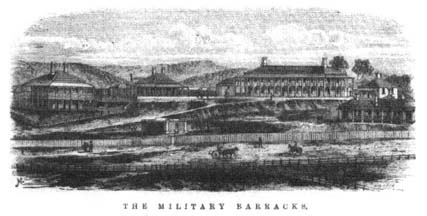

The 50th Regiment Military Guard and the St Helena Penal Establishment, 1867-69

One aspect of the service of the Brisbane 50th Regiment Garrison rarely acknowledged was utilisation of elements of the available personnel as a Military Guard during the construction and initial years of operation of Her Majesty's St Helena Penal Establishment in Moreton Bay, 1867-69. Although the surviving documentation is not clear, the soldiers who made up the Military Guard appear to have been regularly rotated with the rest of the garrison in Brisbane. The numbers of soldiers involved in this Military Guard are not clear, though figures sometimes referred to range from eleven to sixteen (including a Non-commissioned Officer in charge). Again the surviving records do not make it clear how long such soldiers served on St Helena, but it does appear each Military Guard detachment served at least several weeks at a time before rotation with another incoming replacement detachment.

Any analysis of the formative stages of the construction and development of the Penal Establishment on St Helena Island must also acknowledge the crucial involvement and management undertaken by the first Superintendent, John McDonald, who served in this capacity from 1867 until 1882. (126) John McDonald is a significant example of colonial Australian settlers whose prior British (or Honourable East India Company) military service was to prove highly marketable in obtaining employment in the Australasian colonies. In the colonial Queensland setting such former military personages can be widely found throughout the civil services such as the Police, Native Police (as Officers and NCOs), Prisons, Post and Telegraph Departments, the Volunteers, and other government services. Their former Imperial service generally guaranteed access and employment in a variety of such occupations -- for John McDonald this was to include the Queensland Police, Water Police, and then the Prison service.

John McDonald, born in Nairn, Scotland (circa 1837), had joined the British Army and served in the 93rd (Sutherland) Highland Regiment. During this period he saw active service in the Crimean War (1854-56), for which he received the British Crimean War Medal with bars `Alma', `Balaclava', `Inkermann' and `Sebastopol'; as well as the Turkish Crimean War Medal. In correspondence in 1879, McDonald elaborated on his prior Army service and his rise from the ranks to commissioned officer:

```
   I beg to point out that I know discipline in every shape from previous
   training, having served ten years in the 93rd Sutherland Highlanders, as
   private, non-commissioned and subsequently commissioned officer ... on the
   staff of Lord Raglan, and since then held appointments in the Queensland
   service for nineteen years ... (127)
```

In some official 1860s Queensland Govern-ment publications there is reference to John McDonald's first date of appointment in the civil service (either under the Government of New South Wales or Queensland) as 26 February 1861. It is unknown what position this actually was, but from his subsequent service in 1862 onwards, a police role would seem highly likely. On 15 February 1862, John McDonald who was stated to be Acting Sergeant was promoted to rank of Sergeant, and Sergeant in Charge at the Brisbane Police Station. On 10 October 1862, John McDonald was appointed Inspector of Water Police for the Port of Moreton Bay. As Inspector of Water Police, John McDonald then obtained appointment as an Officer of Customs (`Coast Waiter') on 20 January 1863. After this McDonald became Keeper of the Hulk Proserpine (128) on 18 May 1864, and for which he was appointed Gaoler of this prison hulk on 1 June 1865. (129) In this transmission from Police, Water Police, to Gaoler of the prison hulk Proserpine, McDonald became intimately associated with the establishment of the Penal Establishment on St Helena Island during 1866-67. In assessing the initial stages of building and works on the island, the Colonial Architect relayed in early 1867:

```
   Some eighteen prisoners had been employed on the Island of St Helena from
   February 1866, first in the erection of a Lockup, and latterly in the
   construction of the two buildings, under the supervision of a Foreman of
   Carpenters, assisted by one freeman for the better joiner's work, the
   prisoners passing backwards and forward to the Hulk `Proserpine' anchored
   off Fisherman's Island, some four or five miles distant, until within the
   last two months [November 1866], when the Hulk was removed to an anchorage
   nearer the Island in order to allow the full compliment of prisoners to be
   put to work at the new Convict depot, in finishing the buildings above
   mentioned, clearing the scrub, and completing a jetty near the Lockup.
   (130)
```

John McDonald's importance in the works under way, and the control of the prisoners being employed, was confirmed by appointment as the first Superintendent of the Penal Establishment at St Helena on 14 May 1867. (131) Superintendent McDonald quickly established himself as an imposing disciplinarian presence on St Helena, a position he maintained until resigning on 4 April 1882. (132) William Townley the second Superintendent at St Helena -- another former Imperial officer who had served in the Military Train, and later captain in the Queensland Volunteer Artillery (1875-77) -- was appointed to this position on 17 October 1883, though this appointment was backdated so as to take effect from 1 May. (133)

The Colonial Architect's report dated 10 January 1867, indicates some building construction had already taken place on St Helena as the island was initially intended to become a Quarantine Station. With the `project of making St Helena a Quarantine Station being abandoned' these buildings were converted `into convict buildings' so as `to meet the demand for extra prison accommodation' when it was decided to instead use the St Helena for that purpose. (134) This report also included details on the pro-posed accommodation on the eastern side of the island of the Military Guard who were shortly expected to commence duties:

```
   The prisoners are now engaged on these works and one of the buildings, that
   on the West Side of the bluff, will be ready for the reception of about 60
   prisoners in the course of a week ... but as it is the intention of the
   Government to put a military guard over the prisoners on St Helena, and no
   shelter being as yet available, the prison wards cannot be used until the
   building on the East bank has been temporarily fitted up for the reception
   of the guard, and this cannot be finished for some three or four weeks to
   come, as the roof is not yet on the building, and the work being done by
   prisoners, a longer time is required than if it were being done by free
   men. (135)
```

Following the receipt of approval of Governor Bowen, the role and duties of the Military Guard for St Helena on 14 May 1867 comprised:

```
   The military guard stationed at St. Helena will be under the immediate
   control of the NCO whose Duty it will be to co-operate with the
   superintendant, and do all in his power to establish the security of the
   prisoners by night and day, and maintain order and repress insubordination
   on the part of such prisoners.
```

The NCOs in command of the military guard will act under instructions having been submitted to, and approved by, His Excellency the Governor in Council. (136)

To assist the Non-Commissioned Officers of the 50th who were placed in charge of this Military Guard, `Instructions' were also set out during November 1867 which elaborated upon their duties while stationed at the St Helena Penal establishment:

```
   1. The Non-Commissioned Officer will be responsible for the conduct of the
   men, under his charge.

   2. He will see that all Standing Orders and other Instructions which may be
   issued from time to time, are strictly and promptly executed, and shall
   duly report any neglect of the same.

   3. It is not desirous to lay down any precise course of conduct for the
   Non-Commissioned Officer, or to say how much of his time should be occupied
   in the actual performance of his duties, but he will at all times
   co-operate with the Superintendent and render every assistance in his power
   for the maintenance of good order and the general security of the
   prisoners.

   4. He will feel the importance of making occasional visits to the Sentries,
   seeing that they are on the alert and attending to their duty.

   5. He will inspect every sentry before turning him out on duty, see that he
   is perfectly sober, clean, correctly dressed, armed and accoutred that his
   rifle is loaded and capped, and that he is supplied with ten rounds of
   ammunition and a proportionate number of caps, all of which must be in good
   condition. He will then march them to their respective posts, and see that
   the Sentries on numbers One, Two and Three posts do duty with fixed
   bayonets.

   He will attend at every muster of the prisoners with the proper number of
   Sentries requited for duty. Station them at their respective posts, and see
   that each Sentry fully understand the instructions relating to his post.

   He will see that the Sentry for number `Three' post is on duty at the time
   the prisoners are released from their Cells in the morning, and that he
   does not leave it until after the hoisting of the `All right' signal at
   night.

   He will understand that `Night Duty' is from the time the prisoners are
   locked up in the evening until they are released in the morning and will
   post his Sentries accordingly.

   Day Posts

   No.1. is in front of the Prison Buildings

   No.2. is at the south-east corner of the Yard to command a view of the
south and east angles.

   Night Posts

   No.1. is in front of the Prison Buildings including the ends.

   No.2. is at the back of the Prison Buildings within the Yards including the
   Hospital and Cook House.

   No.3. Day Post only -- is at the Stone Quarry on the beach, to command a
   view of all the south end of the Island and a portion of the West Side.
   (137)
```

Apart from the instructions for use by NCOs, the Privates of the 50th who would serve as part of the Military Guard were also provided with lengthy and detailed `General Instructions' for their guidance. (138)

The formalisation of procedures and instructions for both NCOs and Privates serving in the Military Guard appear to have been at least partially instituted following complaints by Superintendent John McDonald about the manner these Soldiers were carrying out their tasks to the perceived detriment of operations of the Penal Establishment.

On 31 October 1867, McDonald outlined to the Colonial Secretary:

```
   I have ... [found] fault on several occasions with the manner in which some
   of the military guard performed their Duties ... and more especially when
   on the points of landing. That orders on that post, or part of the orders
   is not to allow any person to land without the written order of the
   Colonial Secretary or Visiting Justice. But some of the military do not pay
   the slightest attention to the above order and their attention has been
   especially called to the part of their orders by the NCO in charge of the
   guard.

   On several occasions persons have been allowed to land from the steamer
   `Kate' without the sentries demanding their authority and allowed to pass
   to the prison, the consequence is that anything might be passed to the
   prisoners at work all over the island. It is necessary that the above order
   should be strictly carried out; there is another matter I should bring
   before your notice, viz, of sending Lance Corporals in charge of the guard
   who do not appear to have the least control over their men which is not the
   case with a full Sergeant or full Corporal. I think if the matter was
   brought before the notice of the Capt. Commanding the troops, that he would
   cause the duties to be more satisfactorily performed in future. (139)
```

Shortly after McDonald again followed up his concerns with another complaint about the behaviour of the Guard in December 1867:

```
   I had to complain to the visiting justice of the careless manner in which
   the military guard perform their duties. [This?] month I found soldiers
   while on guard talking with prisoners, and on one occasion I found one of
   them sitting down reading a book while on prison guard, there seems to be a
   great lack of discipline amongst the guard, as a rule, I have reason to
   believe that the guard conveys letters to and from prisoners on the island,
   and the prisoners are kept as well informed of all passing events as if
   they were in Brisbane Gaol! While such conduct amongst the guard which I
   have to depend so much upon, is allowed to be carried on, what confidence
   can be placed in them, there are some of the men trustworthy but, very few
   of them can be trusted out of sight with prisoners, I have on several
   occasions reported the men to the NCO in charge who very often is a
   L/Corporal who has little or no control over their men, if there is not
   soon a change for the better in the conduct of the military guard it will
   be quite impossible for me to carry out that order and discipline that
   should be carried out on the island. (140)
```

Correspondence in January 1868 indicates that Superintendent McDonald made a specific charge of `negligence of duty' against a Private Poynter, one of the Military Guard who had just been released from duty on St Helena. Captain Eden, 50th Regiment, Commanding the Troops, informed the Colonial Secretary he had `in accordance with the desire of the Visiting Justice' taken action in the matter, though countering that this was only carried out as far as `the conflicting evidence I have gathered will permit'. (141)

On 1 February 1868, Superintendent McDonald reported to the Colonial Secretary that the `large prison building' under construction was expected to be completed by the end of March. Once this building was ready this would allow for the accommodation for 150 prisoners on St Helena. McDonald again used this forum of his regular report as an opportunity to again complain about the Military Guard, suggesting in the process, Warders be used to replace them:

```
   If the prisoners are increased to the above number the number of warders
   will also have to increase, there ought to be one warder for every ten ...
   prisoners together with the military guard as at present established on the
   island. I would recommend that three warders be substituted for the
   military guard. The guard is of no service in charge of prisoners at work
   as they do not take the slightest interest, and pay little or no attention
   the orders I give them; and as a rule they make free with the prisoners, so
   that it is impossible to carry out the same discipline that could be
   carried out with warders. (142)
```

For those soldiers who were tasked with service on St Helena -- they too had complaints of their own regarding the conditions of their accommodation and the rations they were expected to tolerate. On 3 March 1868, Lieutenant MacGregor, 50th Regiment, temporarily `Commanding Troops', wrote to the Queensland Colonial Secretary about certain grievances of the men who had served in the Military Guard detachment:

```
   I have the honour to bring to your notice the aged and dirty state of the
   beds provided for the military guard at St. Helena, and beg to request that
   you will cause the proper authorities to provide new ones at once. There
   being no change of beds, or bedcovers, nor means of [?] them I am unable to
   cast any blame on the soldiers of the guard.

   I have also to request your attention to the inferior quality of the tea
   ration which is far below that required by the ordinary Commissariat
   contract. (143)
```

On 17 June 1868, Captain Eden, the officer now commanding the 50th Regiment detachment in Brisbane, in a detailed correspondence, also brought a variety of complaints of the men of the Military Guard before the Colonial Secretary.

```
   With a view to its receiving your early attention I ... bring to your
   notice that the Detachment 50th Regt, last returned from St. Helena ... on
   the 8th Inst. complain in a body of the inferior quality of the rations
   issued to them at that station. I understand them to say among other things
   that for the space of their days they had no Bread whatever, and that no
   potatoes were issued to them for, I think, a period of eight days. I am
   informed that in the first case a certain quantity of some description of
   flour was presented to them, in place of Bread with a suggestion that they
   could make their own ... The scale for the Issue of Rations to the Troops
   at St Helena, if I remember right, was authorized by yourself, and provides
   for a daily portion of bread and potatoes for the soldiers.

   I also ... bring to your notice a pretty general complaint from the
   soldiers (and noncomd. Officers in charge) that have of late been stationed
   at St Helena regarding Mr. Turnkey Hamilton, who, by the way, I understand
   to be the Issuer above alluded to -- his manner to them they designate as
   most irritating and annoying ...

   I can quite believe this complaint to be exaggerated by irritation, still,
   judging from the well known character of many of my informants, I am
   convinced that it contains sufficient grounds to warrant ... the attention
   you may find it to deserve. (144)
```

In this Captain Eden also confirms visiting St Helena on a number of occasions, during which he naturally would have inspected the accommodation, duties and procedures of the Military Guard at this penal station. Other complaints raised by the men were of offensive language or manner of the Chief Warder, James Hamilton, towards them; `the total, or partial absence of Sentry Boxes' for the protection of sentries during inclement weather; and `great complaints concerning an offensive cesspool' located near one guard post. But it was the actual duties that these soldiers were expected to perform, and the numbers of men from the Military Guard used as sentries at any one time that was also of concern to Captain Eden:

```
   ... the fact that they are a great deal to arms, and, as I rather think,
   not sanctioned by the `Queens Regulations'. With respect to this I
   mentioned my objection to Mr Superintendent Macdonald, stating I could not
   allow the use of five sentries from a guard of but eleven effective men. My
   objection appears to have had no use yet with him, for I have ascertained
   that he regards the military Regulations, as expressed through me, with no
   attention whatever, and still continues to employ more sentries than the
   Guard can properly furnish. (145)
```

This correspondence, combined with McDonald's incessant complaints, shows that there existed a considerable conflict of authority and purpose between the Imperial and Colonial authorities that played a role in the operations on St Helena in this initial establishment phase. Similarly, a clash of egos was also no doubt at play, where any questioning of the manner in which Superintendent McDonald operated his prison fiefdom, received strong rebuke, as it did when criticisms were levelled at the Military Guard, so did Imperial Officers react in defence of their men.

Of course another aspect to the role of the Military Guard on St Helena was the unenviable position in which soldiers might at any time find themselves called upon the fire on prisoners. Such a situation was a glaring potential conflict between Army and civil jurisdiction, as it was liability in case of death or injury that might be inflicted by a soldier. Such a situation was a glaring potential conflict between military and civil jurisdiction since whatever action a soldier took in performing his duty which may have resulted in the death or injury of a prisoner did not exempt him from prosecution under either codes of law. In June 1868, Captain Eden requested through Visiting Justice Barron, that the `instructions for the guidance of the Military Guard' be amended by the Government so as to provide more detail than those already in use on St Helena. After receiving the Government's response, Captain Eden replied on 16 June:

```
   I believe it to be necessary, before these instructions can be put in
   force, that some addition to them should be made, that shall regard the
   necessity for using the loaded Rifles put into the soldiers hands, and
   explicitly set down when, and from whom an order to fire on a `prisoner'
   shall be considered valid, and an exemption from any ulterior consequences
   that might arise out of such as act, the result of which was the wounding
   or death of a Prisoner. I am convinced that some rule providing for an
   emergency of this sort should be laid down and thus tend towards the
   greater efficiency of the St Helena Detachment.

   Rule No.11, of `General Instructions' only forbids the discharge of a Rifle
   without the Superintendents sanction with a view to prevent any false
   alarm, and, consequently, denies the Soldier that means of giving warning
   when a real alarm is necessary, which, it is to be presumed, may occur
   [soon?] at St. Helena. (146)
```

Captain Eden concluded with the hope the Government would give this their immediate attention so he could implement these `revised instructions into force' the following week.

Despite the ongoing simmering antagonism between Superintendent McDonald and the soldiers who were employed as part of St Helena's Military Guard detachment during 1867-69, these Imperial troops nonetheless played an important temporary prison staffing role while the penal establishment was being constructed. (147) The prison stockade was not finished until 1868, during which time these soldiers were especially important for mounting guards over the various prisoner work gangs and manning strategic posts on the island. Amongst the findings of the 1869 Select Committee into expenditure and management on St Helena, exists a breakdown of the annual costs involved with the Military Guard:

```
   Original payment, by Government, for fifteen privates and one
   non-commissioned officer--in all sixteen men--at 40 [pounds sterling] per
   annum: Total = 640 [pounds sterling] 0s. 0d.

   Extra allowance to fifteen privates for acting as a penal guard, at 1s. per
diem:

      Total = 273 [pounds sterling] 15s. 0d.

      Extra allowance to one non-commissioned officer, for penal guard, at 2s.
      6d. per diem: Total = 45 [pounds sterling] 12s. 6d.

      Total Cost of the `extra allowances' for the 15 privates and 1 NCO: =
      319 [pounds sterling] 7s. 6d. Rations for sixteen men, as above, at 10
      [pounds sterling] Ss. 4d. each per annum: = 164 [pounds sterling] 5s.
      4d. Total cost for military guard = 1,123 [pounds sterling] 12s. 10d.
      (148)
```

Despite the fact that these Imperial soldiers were initially utilised in this prison guard role because of the parsimonious stance of the Queensland Colonial Government, they nonetheless carried out their duties effectively, despite the problems associated, and in the process added a `scarlet' (149) page to St Helena's history.

The Departure of the Last Imperial Garrison in Moreton Bay, March 1869

Queensland experienced the garrison service of elements of the 50th Regiment until ordered to rejoin the main body of the Regiment for departure for England in 1869. The 50th detachment subsequently embarked aboard the troopship Himalaya on 10 March, departing Moreton Bay on 11 March. (150) The Courier relayed an account of the 50th detachment's final `inglorious' moments in Brisbane, including the removal of the last Military Guard at the St Helena Penal Establishment on 10 March:

```
   The company of the Queen's Own 50th Regiment ... embarked yesterday aboard
   the Himalaya, which is now lying in Brisbane Roads. The [steamer] Kate ...
   left town early in the forenoon for the penal station at St. Helena, with a
   party of police to relieve the military guard there. The soldiers, sixteen
   in number, were then taken on board the Kate, and conveyed to the Himalaya.
   The soldiers in town, sixty-four in number (nearly all of whom seemed
   intoxicated), with their officers, Captain Eden, Lieutenant Macgregor, and
   Ensign Bromfield, were taken to the ship in the A.S.N. Co.'s Diamantina,
   which was chartered for the purpose of conveying the troops to the
   transport. On the way down the river an incident occurred which for the
   moment created some little excitement. Just as the steamer got abreast of
   the Custom House one of the privates, who appeared loth [sic] to leave
   Brisbane, suddenly jumped overboard with the intention of swimming
   ashore.... he was picked up immediately, with no further hurt than a good
   ducking. He made some resistance to getting into the steamer ... Finally,
   however, he was taken on board, where he was secured in a manner that
   prevented his getting into further mischief. The Diamantina having
   transhipped the men to the Himalaya, returned to town ... It was expected
   that she would bring up the company of the 18th Royal Irish but there were
   no troops on board for Brisbane. (151)
```

The departure of the 50th Regiment Detachment from Brisbane did not as it turned out, see the arrival of a replacement detachment from the 2nd Battalion 18th (Royal Irish) Regiment, the last Regiment of the Line to serve in Australia. This is despite being contemporarily reported as expected, and even as arriving in Moreton Bay. (152)

The detachment of 50th Regiment was in fact the last Imperial force to be stationed in Moreton Bay, though individual Army and Navy officers were to continue to see service in Queensland on secondment. (153) The Courier on 12 March 1869 pointed out:

```
   This colony is for the present without soldiers, as the detachment of the
   50th Regiment recently stationed here left ... and the company of the 18th,
   which was to have taken their place, was, for some cause or other, not
   allowed to leave New Zealand. So far from regarding this as a misfortune,
   we are disposed to look upon it with the utmost complacency, and would even
   go as far as to suggest to the Government the desirability of seriously
   considering the propriety of getting along for the future without any
   military. (154)
```

The delay in the 18th Regiment departing for Australian garrisons was actually as a result of the renewed conflict that had broken on both the West and East Coasts of the North Island of New Zealand during 1868 into early 1869. On 9 January 1869, a military party consisting of Major-General Sir Trevor Chute and Colonel Hyde Page left Melbourne for New Zealand, via Sydney aboard the steam ship Hero. (155) Despite the fact that Major-General Chute's visit was reported as a routine inspection of the British regular troops in New Zealand, it was also an obvious opportunity for the most senior Imperial officer in Australasia to judge first-hand the seriousness of the situation in that Colony. Chute's decision to temporarily delay the removal of the 18th Regiment then stationed in New Zealand, was later reported as having had a beneficial effect on public affairs of this Colony, where the reassuring presence of `redcoats' bolstered morale in threatened townships such as Wanganui. (156)

Apart from New Zealand yet again having an impact on the availability of Imperial military forces for Queensland and the other Australian Colonies, Queensland in 1869 made a financial and political decision whereby it refused the Company of the 2/18th Regiment that was to be allocated. Correspondence from Army Headquarters in Melbourne, in June 1869, on the distribution of troops with the 2/14th Regiment being ordered to England, and the 2/18th Regiment in the process of departing New Zealand, confirmed that the `Government of Queensland ... [was] not desiring the presence of Imperial Troops'. Tasmania instead was in turn to be provided with two Companies instead of one initially planned. (157) Queensland's refusal of this Company of the 18th Regiment -- a far cry from the early 1860s when despite Governor Bowen's repeated correspondence, he was never able to achieve adequate troop numbers -- signalled the end of Queensland's Imperial presence. In 1870 the last of the remaining British Army detachments were withdrawn from the Australian colonies and many contemporaries saw this not only as the end of an era, but not unlike the withdrawal of Rome's legions from Britain with the same sense of trepidation for the future. Yet this fear was greatly off-set by two comforting facts, that the Royal Navy maintained its presence in Australian waters until 1913, and that the Australian colonies, and subsequently the new Commonwealth, now had its own well established defence forces -- an enduring legacy of the British Army.

(1) Jeff Hopkins-Weise and Rod Pratt are both currently completing their respective History PhD theses which each deal with aspects of the history of the British Army in Australasia. Jeff's research thesis is on Australian Involvement in the New Zealand Wars of the 1840s and 1860s', and Rod's is 'The British Army at Moreton Bay, 1824-1869'. Both have co-authored a book manuscript entitled: Brisbane's 50th (Queen's Own) Regiment Detachments, 1866-69: & the Saint Helena Penal Establishment Military Guard, which is soon to be published in 2001.

(2) For the case of The Sudan Contingent from NSW in 1885 one should study Donald C Gordon, The Dominion Partnership in the Imperial Defence 1870-1914. Published by The John Hopkins Press, Baltimore, USA in 1965. See Chapter 4 -- Colonial willingness to serve.

(3) This central tenet of Earl Grey's policy is covered in greater depth in Earl Grey's The Colonial policy of Lord John Russell's administration, Vol. l (London, Richard Bentley, 1853); and Robert L Schuyler's, "The recall of the Legions -- a phase of the decentralization of the British Empire", American Historical Review, Vol 26, (1920), pp 18-36.

(4) CO 234/1, Bowen to Newcastle, 4 April 1860. Public Record Office (London) [hereafter abbreviated PRO].

(5) Interested readers are referred to Duncan Anderson's, "Sir George Bowen and the Problems of Queensland's Defence, 1859-1868", Queensland Heritage, Vol 2, No 3, (Nov 1970), pp 32-38.

(6) The term `Australasia' used throughout this analysis represents the broad social, economic, and geographical 19th century region comprising Australia and New Zealand. This is carried out in terms of placement within an Empire history framework, as well as acknowledgment of the shared colonial experience. It is recognised by these authors that in New Zealand today the term is rarely used because of its negative connotations of over emphasis of the Australian component, to the almost total exclusion of the New Zealand element in its usage.

(7) P Burroughs, "Imperial Defence and the Victorian Army", The Journal of Imperial and Commonwealth History, Vol 15, No 1, (Oct 1986), p 58.

(8) Ibid, p 63. In this theme Burroughs makes specific mention of the contributions of the Royal Engineers `to improved communications in the empire through exploration, surveying and mapping, as well as the building of railways and canals', and for which has yet to receive proper due historiographical acknowledgment (refer to p 61).

(9) For examples of such histories, refer to: D H Johnson, Volunteers at Heart: The Queensland Defence Forces, 1860-1901 (St Lucia, Qld: University of Queensland Press, 1975); Ivan Bates, Queensland Mounted Units, 1860-1940 (Brisbane: Victoria Barracks Historical Society, Inc, 1988), and his Commanders of Queensland Mounted Units, 1860-1940 (Brisbane: Victoria Barracks Historical Society, Inc, 1990); James Grant Ritchie, Officers of the Western Australian Defence Force. 1861-1901 (Swanbourne: John Burridge Military Antiques, 1988), and his From captains to colonels: a photographic account of the development of the Western Australian Defence Force from 1861 to 1901 (Swanbourne: John Burridge Military Antiques, 1991); D M Wyatt, A lion in the colony: an historical outline of the Tasmanian colonial volunteer military forces, 1859-1901 (Hobart: Anglesea Barracks, 1990); Andrew & Sandra Twining, South Australian military volunteers for 1855 (Kogarah, NSW: the authors, 1992); A F Harris, South Australian Military Forces (Adelaide: the author, 1996); G F Ward, Victorian Land forces, 1853-1883 (Melbourne: the author, 1989); Bob Nicholls, The colonial Volunteers: the defence forces of the Australian colonies, 1836-1901 (Sydney: Allen & Unwin, 1988); Craig Wilcox, For heaths and homes: citizen soldiering in Australia, 1854-1945 (St Leonards, NSW: Allen & Unwin, 1998); Robert Darlington, Sudan to Vietnam (Drumoyne, NSW: Shakespeare Head Press, 1987).

(10) Examples of Australian enlistees into the 12th Regiment include: William Barrett (born London, Middlesex), Private, No 722, enlisted Sydney, NSW, 2 July 1860, and deserted from Brisbane Detachment of the 12th Regt, 14 May 1861. Archibald Devine (born Plymouth, England), Private, No.836, enlisted 17 February 1862, Sydney, NSW, and deserted from Brisbane Detachment of the 12th Regt, 20 February 1863. Edward C Prince (born Alexandria, Sydney, NSW), No.253, enlisted Sydney, NSW, 4 March 1859, and deserted at Pokeno, New Zealand, 26 May 1862. Robert Graham. (born Ireland), Corporal, No 1074, enlisted NSW, 27 August 1863, and discharged in New Zealand, 20 April 1867. The Queensland Government Gazette, Vol.III, No 52, 28 June 1862, p 305; Queensland Police Gazette, Vol 1, No 2, 3 August 1864, p 7; Rod Pratt, Nominal Rolls of the 12th & 50th Regiment Detachments in Queensland, 1860s (Rolls compiled from ongoing PhD research into `The British Army at Moreton Bay, 1824-1869'); R Sexton, The Deserters: A Complete Record of Military and Naval Deserters in Australia and New Zealand 1800-65 (Magill: Australasian Maritime Historical Society, 1985), pp 56 & 70; and H & L Hughes, Discharged in New Zealand: Soldiers of the Imperial Foot Regiments who took their Discharge in New Zealand: 1840-1870 (Auckland: The New Zealand Society of Genealogists, 1988), p 13.

(11) Interested readers are referred to Hugh Cunningham's, The Volunteer Force, a social and political history 1859-1908 (Hamden [Connecticut]: Archon Books, 1975), and Glenn A Steepler's, Britons, to arms!: The story of the British Volunteer soldier and the Volunteer Tradition in Leicestershire and Rutland (Gloucestershire: Budding Books, 1997).

(12) The 70th Regiment of Foot served in New Zealand during 1861-66. For details of this regiment's service in these campaigns (including reference to Captain D M Fraser on p.324), refer to: H W Pearse, History of the 31st Foot Huntingdonshire Regt [&] 70th Foot Surrey Regt Subsequently 1st & 2nd Battalions The East Surrey Regiment: Vol. 1. 1702-1914 (London: Spottiswoode, Ballantyne & Co. Ltd., 1916), pp.321-334.

(13) For history of the service of the 80th Regiment in Australia and New Zealand, refer to: James P Jones, A History of the South Staffordshire Regiment: (1705-1923.) (Wolverhampton: Whitehead Brothers Ltd, 1923); W L Vale, History of the South Staffordshire Regiment (Aldershot, Great Britain: Gale & Polden, 1969); and J Bryant Haigh, "The 80th Foot in New Zealand". Bulletin of the Military Historical Society, Vol 26, (1976), pp 79-83.

(14) Donald Maclean Fraser, Captain 70th Regiment, who died in London on the 19th September, 1864, at the early age of thirty-six, was the youngest son of the late Captain Simon Fraser, of the 80th Regiment, who was killed while gallantly leading on his men at Ferozeshah [sic], in India.... leaving his widow, Mrs Frazer, of Liverpool, New South Wales-and five children on the plains of Umballs, within hearing of the cannon roar.... He served with the 80th Regiment in the Burmese war of 1852 and 1853 ... He also served in the suppression of the Indian Mutiny in 1858 ... [and] also during the New Zealand war. Captain D M Frazer was ... a most devoted son-devoting a great portion of his means towards assisting his fond and widowed mother, up to the time of his decease .... deeply regretted by his brother officers and a very large circle of friends in New South Wales, India, and England.' The Sydney Morning Herald, 16 December 1864, p 4.

(15) Refer to, Henry Marshall's On the enlisting, discharging and pensioning of soldiers with the official documents on these branches of military duty (Edinburgh: Adam & Charles Black, 1839).

(16) A R Skelley, The Victorian Army at Home: The Recruitment and Terms and Conditions of the British Regular, 1859-1899 (London: Croom Helm Ltd., 1977), p 251; M. Barthorp, To Face the Daring Maoris: Soldiers' impressions of the First Maori War 1845-47 (London: Hodder and Stoughton, 1979), p 27; and Hew Strachan, Wellington's legacy: the reform of the British Army, 1830-54 (Manchester University Press, 1984), pp 70-75.

(17) J H Heaton, Australian Dictionary of Dates and Men of the Time: containing the History of Australasia from 1542 to May, 1879 (Sydney: George Robertson, 1879), p 139.

(18) M Austin, "The First Australian `Digger': John Cox of the New South Wales Corps", Sabretache, Vol 27, No 1, (Jan-March 1986), p 13. Also refer to the following seminal works that have attempted to resurrect the history of the British Army in Australia: M Austin, The Army in Australia 1840-50: Prelude to the Golden Years (Canberra, ACT: Australian Government Publishing Service, 1979); and P Stanley, The Remote Garrison: The British Army in Australia 1788-1870 (Kenthurst, NSW: Kangaroo Press, 1986).

(19) Peter Stanley, "Heritage of Strangers: the Australian Army's British Legacy". Australian Defence Force Journal, No 87, (March/April 1991), p 24. For discussion of this experience in respect to the formation and development of New Zealand's colonial forces, refer to, Jeff Hopkins-Weise, "A History of the Colonial Defence Force (Cavalry): and the Australian Context". The Volunteers: The Journal of the New Zealand Military Historical Society, Vol 26, No 1, (July 2000), pp 5-25.

(20) Rod Pratt coined this phrase `inter-colonial fluidity' during a research discussion with Jeff Hopkins-Weise on this theme of cross-Tasman connections and the movements of serving or discharged British soldiers throughout Australasia, March 2000.

(21) Examples of such occurrences can be witnessed in June 1866 when the Argus published information received from New Zealand where approximately seventy men of the 40th Regiment who had discharged in that Colony had left for Victoria for the purpose of settlement. The Argus concluded that "[t]hey are all men of excellent character", while also acknowledging that numbers of other discharged soldiers from this Regiment were also remaining in Auckland. The Argus, 27 June 1866, p 1. Presumably numbers from amongst this group of discharged 40th Regiment personnel were formerly members of the garrison stationed in Victoria, or those from Tasmania or South Australia up to 1863.

(22) Other confirmed former Brisbane 12th Regt Detachment personnel who took discharges in New Zealand in 1867 are: No 514 Pre Thomas Allan (also as Allen), discharged 19 May 1867. No.150 Pte Henry Thurman, discharged 14 March 1867. No 263 Cpl/Pte Michael McMahon, discharged 14 March 1867. No 2915 Drummer John Hughes, discharged 26 Jan 1867. No 3540 Pte John Milmoe, discharged 10 April 1867. No 59 Pte George Rowson, discharged 9 May 1867, and No 35 Pte Edgar Woodard, discharged 20 April 1867. Further research may in fact show apart from Privates Clancy and Cahill, that others similarly made the return voyage to Queensland to settle after obtaining their discharges. A `Thomas Allen' was appointed as a Customs Officer in Townsville on 1 February 1873, but as yet unable to confirm whether this individual the same as former No 514 Pte Thomas Allen. Queensland: Blue Book for the Year 1881; Compiled from Official Returns in the Registrar-General's Office (Brisbane: James C. Beal, Government Printer, 1882), p 49; Rod Pratt, Nominal Rolls of the 12th & 50th Regiment Detachments in Queensland, 1860s (Rolls compiled from ongoing PhD research into `The British Army at Moreton Bay, 1824-1869'); and H & L Hughes (1988), op cit, pp 12-15.

(23) Pte Patrick Clancy (also as Clancey), Regimental No 3500, enlisted in the 12th Regiment as a `Volunteer from Limerick' on 22 January 1856. After arrival with a regimental draft that same year he served in Hobart and Launceston. In Launceston he met and married Mary Marinan on 16 December 1857, and thereafter served in NSW during 1858-62. On 23 July 1862, Clancy arrived in Brisbane with a detachment of thirteen rank and file of the Regiment and served in Queensland until October 1866 when all the 12th Brisbane Detachment was ordered to rejoin the Regiment in New Zealand, arriving in Auckland (via Sydney) on 12 November 1866. On 14 March 1867 he took his discharge and was given a 1 [pounds sterling] gratuity after 11 years service with the Regiment. Clancy promptly returned to Brisbane and applied direct to his former Commanding Officer of the Brisbane 12th Regiment Detachment, Lieutenant D.T. Seymour, now Queensland's first Police Commissioner, to join the Police Force on 1 May 1867. Clancy was promptly appointed Constable (No.231) and served in this force until he was pensioned on 1 March 1888. Patrick died on 12 January 1899 and is buried in a family plot in Brisbane's Toowong Cemetery. A/38739 AF225: Queensland Police Service File: Patrick Clancy, Queensland State Archives; Oath Book: 14 March 1866 -31 December 1867 [No.375 Patrick Clancy, 4 May 1867], and Register of Members of the Police Force: 1856-1917, Queensland Police Museum; Queensland Police Gazette, Vol 4, No 6, 5 June 1867, p 39; and Genealogical history on Patrick Clancy, Private 12th Regiment Brisbane Detachment and New Zealand war veteran, and history of the Clancy (and associated Kiely) family of Queensland, courtesy of Jodie Healy (descendant, of Brighton, NSW) to Jeff Hopkins-Weise (Dec. 1997-July 1998). Patrick Clancy's NZ War Medal is in the research collection of Jeff Hopkins-Weise.

(24) Pte Daniel Cahill, Regimental No 296, was born in Manchester and enlisted in the 12th Regiment on 3 August 1859, saw service in Queensland as a member of this Regiment's Brisbane Detachment before departing for NZ in October 1866. Cahill took his discharge in NZ on 14 March 1867, the same day as Patrick Clancy. Cahill possibly returned to Queensland in company with Clancy, where he also joined the Police Force on 8 May 1867. Cahill did not remain in the police long, and in April 1869 became a Letter Carrier at the Brisbane General Post Office. Another former 12th Regiment soldier, Benjamin Joyner, residing at Gladstone in 1913, recalled both Cahill and another former 12th Regt soldier, William Craft, being employed in the Brisbane Post Office for many years. "The Old Burial Ground", The Brisbane Courier, 13 October 1913, p 6; Oath Book: 14 March 1866 -- 31 December 1867 [No.378 Daniel Cahill, 13 May 1867], Queensland Police Museum; Queensland: Blue Book for the Year 1869; Compiled from Official Returns in the Registrar-General's Office (Brisbane: James C Beal, Government Printer, 1870), p 48. No 3361, Private William Craft [also as Croft], 12th Regt, is a confirmed member of this Regiment's Brisbane Detachment 1864-65, and appears to have taken his discharge whilst in Queensland before the Detachment was ordered to New Zealand in October 1866. Craft obtained appointment in the Brisbane General Post Office on I September 1866, and Government records indicate he served as a Letter Carrier for the Post Office in Brisbane, Mackay and Rockhampton from 1866 until as late as 1899-1900.

(25) A/6810: Queensland Treasury, Imperial Pension Register, 1872-99. Queensland State Archives [hereafter abbreviated QSA].

(26) The Moreton Bay Courier, 13 July 1850.

(27) Petitions requesting troops for Brisbane's defence first began with the withdrawal of the 99th Regiment in June and September 1848 and, upon hearing the 11th Regiment was to be withdrawn, another petition in January 1850. The Moreton Bay Courier, 22 July 1848, 2 September 1848, and 5 January 1850.

(28) CO234/3, Bowen to Newcastle, 6 August 1859. PRO.

(29) CO234/1, Bowen to Newcastle, 4 April 1860. PRO.

(30) The issue of having a `nucleus' of British regulars was by far Bowen's most frequent argument in requesting such a force and constitutes a major theme in thirteen despatches to the Colonial Secretary between 1859 and 1866.

(31) CO 234/3, Lugard to Merivale, 29 August 1859. PRO.

(32) The Brisbane Courier, 8 September 1860.

(33) The Brisbane Courier, 15 January 1861.

(34) The Brisbane Courier, 21 May 1864.

(35) The Brisbane Courier, 25 May 1866.

(36) The Brisbane Courier, 24 & 26 June 1862.

(37) The Brisbane Courier. 25 June 1862.

(38) The Brisbane Courier. 31 May 1866; & 27 November 1868.

(39) The Brisbane Courier. 16 May 1861.

(40) The Brisbane Courier. 3 October 1861.

(41) The Brisbane Courier. 27 April 1862; & 20 August 1862.

(42) The Brisbane Courier. 23 December 1863.

(43) The Brisbane Courier. 17 September 1866.

(44) The Brisbane Courier 16 October 1866.

(45) The Brisbane Courier, 20 October 1866.

(46) Major Edward Lewis Burrowes, Deputy Surveyor General Queensland, and late of 97th Regiment, died 24 January 1884, aged 74. His grave is at Toowong Cemetery, Brisbane.

(47) Master purchased his ensigncy in the 58th Regiment on 22 November 1842 and was made lieutenant on 8 December 1847, which was the day after his brother, Lt. Charles Chester Master, was killed along with Lady Mary Fitzroy, Governor Sir Charles Fitzroy's wife, in a carriage accident.

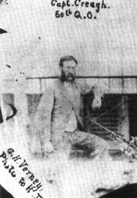

(48) The Brisbane Courier, 8 November 1860.

(49) Gray was made a captain in the 95th Rifle Regiment on 6 May 1809; Major on 7 April 1814; and Brevet-Major on 21 January 1819.

(50) Charles Arrowsmith Bernays, Queensland Politics during sixty years (1859 - 1919) (Brisbane: [s.n.], 1919), pp. 12-13.

(51) A2.42 frame 444-449. Kent to Colonial Secretary, 25 August 1859. John Oxley Library [hereafter abbreviated JOL].

(52) The Brisbane Courier, 15 September 1860; and 16 January 1864; and Queensland Government Gazette, 22 September 1860; and 14 March 1863.

(53) An excellent account of these events is given in Peter Stanley's, The White Mutiny: British military culture in India, 1825-1875 (London: Hurst & Co., 1998).

(54) WO22/297: Returns for Chelsea out-pensioners in Queensland, 1876-1880. PRO.

(55) Edward Deshon was born on 3 January 1836, the son of Lt. Col. Charles John Deshon, late 17th Regt. He was educated at Bath Grammar School. He joined the 68th Regt as an ensign on 6 June 1854. Lieut. 1 Dec. 1854 [and] Retired 22 Oct. 1861. He served with the 68th in the Crimea from 15 November 1854 and was awarded a medal with a clasp for Sebastopol and the Turkish Crimea Medal. After retirement, he joined the Public Service of Queensland ... in 1865, becoming Chief Clerk Public Lands in 1875, Under Secretary of Public Lands in 1882 and a Member of the Land Board in 1884. He was Auditor General of Queensland from 1890 to 1901. Appointed C.M.G. He died in his 88th year, on 4 September 1924 in Kemendine, Coorparoo, Queensland: John Bilcliffe, Well Done the 68th: The Durhams in the Crimea and New Zealand -- 1854-1866 (Patterdown, Chippenham [UK]: Picton Publishing (Chippenham) Limited, 1995), p.215.

(56) The Brisbane Courier, 25 June 1863.

(57) Robert Gray, Reminiscences of India and North Queensland (London: Constable, 1913), p.86.

(58) A/6808: Imperial Pension Register, 1872-99. QSA.

(59) Sergeant, Regimental No.425, Robert Brady, born Banbridge, and at the time of his enlistment on 27 June 1858, described himself as a labourer.

(60) Private, Regimental No.219, John Pike, born Lambeth, and at enlistment on 24 September 1857, described himself as a labourer. Pike never attained a rank higher than private but with almost twelve years experience as a British regular he was more than capable of drilling the volunteers after Brady's departure. Nor does it appear that Pike was ever formally paid for his services with the volunteers.

(61) WO22/297: Returns for out-pensioners, Qld 1876-1880. Reel 3918: Australian Joint Copying Project.

(62) A2.3 frame 212. JOL.

(63) Fraser enlisted in the 56th Regt on 8 June 1815 being transferring to the 46th Regt and again into the 48th Regt whilst in NSW. Fraser was born at Blair Athol and aged 24 at the time of his enlistment. He is described on his enlistment record as a `substitute'. Since a limited conscription existed for service in the war against Napoleon, those who were wealthy enough to pay another man to be his substitute in order that military service could be escaped. In this case, Fraser was George Hartley's substitute.

(64) A2.12 frame 859. JOL.

(65) Constance Campbell Petrie, Tom Petrie's reminiscences of early Queensland (Hawthorne, Victoria: Lloyd O'Neil, 1975), p 2; and J G Steele's, Brisbane Town in the convict days. 1824-1842 (St. Lucia, Qld: University of Queensland Press, 1975), devotes much attention to his work as an engineer at Brisbane.

(66) E V Stephens, "Stephen Simpson, MD, MLC", Journal of the Royal Historical Society of Queensland, Vol.5, No. I, (1953), p 794.

(67) Henry Stuart Russell, The Genesis of Queensland (Toowoomba: Vintage Books, 1989), p 211.

(68) A2.33 frame 321-324. John Oxley Library.

(69) Ibid.

(70) Nehemiah Bartley, Australian Pioneers and reminiscences, 1849-1894 (Sydney: John Ferguson, 1978), p 246.

(71) A2.37 frame 651. JOL.

(72) William Irving had entered the 28th Regt as an ensign on 9 July 1803, and during the war against Napoleon he soon rose in rank to captain, major (4 June 1814), and Brevet-Colonel upon his retirement. Charles Dalton's, Waterloo Roll Call, with biographical notes and anecdotes (2nd ed. London: Naval & Military Press, 1904), p 135, states he "distinguished himself in the Peninsula, and had a musket hall through his right arm at Quatre Bras. He quitted the service in 1826 since both arms had been nearly disabled by wounds". The War Office's official Return of names of the officers in the Army who receive pensions ... (London: War Office, 1818), p.8, also notes that he was granted a pension of 300 [pounds sterling] pa, commencing 17 June 1816. For discussion of the events which occurred in the "Affray" at Yorks Hollow, refer to Rod Pratt's, "The Affray at Yorks Hollow, 28 November, 1849: involving the 11th (North Devonshire) Regiment of Foot at Brisbane Town", Mentioned in Despatches: Newsletter of the Victoria Barracks Historical Society, Brisbane, Inc.: Part 1 (July 1995), pp 6-7; Part 2 (August 1995), p 3; Part 3 (September 1995),

(73) p 3; Part 4 (October 1995), p 8; and Part 5 (November 1995), p.4. Queensland Department of Natural Resources, Sale of Crown Lands, 1842-1859. "Bushman" [pseud. William Wilkes?], "Reminiscences of the Aborigines of Queensland", Darling Downs Gazette, 9 December 1876.

(74) Sullivan's military career is unknown although "Capt McCarthy" may have been Capt. Justin E.D. MacCarthy late of the 40th who was appointed ensign on 16 December 1840, and lieutenant on 29 March 1844 (without purchase).

(75) The Brisbane Courier, 6 March 1866. This was most likely Lt. David Cross Mitchell who was appointed lieutenant of the Dumfries Militia on 13 July 1859. Refer to Hart's Army List for 1860.

(76) A/6808: Queensland Treasury, Imperial Pension Register, 1872-99. QSA.

(77) A useful reference source for these men can be found in, Hugh and Lyn Hughes', Discharged in New Zealand: soldiers of the Imperial Foot Regiments who too their discharge in New Zealand, 1840-1870 (Auckland: NZ Society of Genealogists, 1988).

(78) GOV/22: Governor's Office: Letterbook of Despatches to the Secretary of State for the Colonies: 18 Nov 1859 - 23 Sept 1861: Vol 1: Despatch No 30 (Military), dated Brisbane, Qld, 4 April 1860, p 166. QSA. Also refer to, The Moreton Bay Courier, 7 February 1860.

(79) GOV/A1. Governor's Office: In-letters on Official Subjects. Vol 1: 1859-65. Letter 60/107, 17 April 1860, pp 43-45. QSA.

(80) GOV/A1. Governor's Office: In-letters on Official Subjects. Vol 1: 1859-65. Letter 60/218, 4 July 1860, pp 63-64. QSA.

(81) Queensland Government Gazette, No.48, 25 August 1860, p.274; and The Moreton Bay Courier, 1, 8, & 15 September 1860.

(82) Lt. D.T. Seymour became Queensland's first Police Commissioner, appointed Acting Commissioner on I January 1864, and later confirmed as Commissioner of Queensland Police, 1 July 1864, having retired from the Army by sale of his commission on 12 April 1864.

(83) The Sydney Morning Herald, 10 January 1861, p.4 & 5; The Moreton Bay Courier, 15 January 1861; and E.A.H. Webb, History of the 12th (The Suffolk) Regiment 1685-1913 (London: Spottiswoode & Co., 1914), p.281.

(84) GOV/A1: Governor's Office: In-Letters on Official Subjects. Vol. 1: 1859-65: Letter 62/83, 10 March 1862, pp.329-330. Queensland State Archives. Also refer to, GOV/A1: Letter 62/106, 26 March 1862, p.335, QSA; Anderson (Nov. 1970), op. cit., p.33; and Johnson (1975), op. cit., pp.51-53.

(85) Governor Bowen's incessant attempts to obtain Imperial troops saw him utilise comparisons to the size of imperial forces required in New Zealand to combat the Maori. In Bowen's view this should equate to similar numbers of troops being available to not only provide for Queensland's external defence, but in the knowledge of the internal Aboriginal threat, In May 1865, Bowen outlined reasons to the Secretary of State why Queensland was just as entitled to an adequate force of Imperial troops as New Zealand had received, in this he included an extract from the proceedings of the Queensland Executive Council on 10 May 1865: `It is well known that, during the greater part of the last five years -- a period longer than the Peninsula War, -- the Imperial Government have maintained in the neighbouring Colony of New Zealand, in addition to a powerful Naval Squadron, an army of ten thousand (10,000) regular troops, to assist an increasing population of 150,000 British settlers to defend themselves, not against foreign attack, but against a decreasing remnant of 50,000 Maories; of whom it is positively stated that less than three thousand (3,000) men have been actually in arms against the Crown. In other words, the Mother Country has furnished New Zealand, at a vast cost to herself, with more than three soldiers for every insurgent Maorie, while she has hitherto refused to allow Queensland to pay, at the rate fixed by the Secretary of State, for a detachment of even fifty soldiers to assist in the defence of the capital of this Colony against foreign attack. It will be recollected that the hostile Aborigines in the interior of Queensland are more numerous at most points in proportion to the few scattered settlers than are the Maories in proportion to the British population in New Zealand; and that they have often massacred whole families, as in 1858 and 1861. Some years back it was calculated that even at that date, four hundred British subjects had been murdered by the Natives of this Colony. The entire cost of the Mounted Native Police Corps (a force somewhat resembling the Cape Mounted Rifles) and of the internal defence of Queensland generally, is borne by the Colonists, who do far themselves what has always been done chiefly by the Mother Country in the two other Colonies (the Cape and New Zealand) where the Aborigines are numerous and hostile: GOV/24: Governor's Office: Letterbook of Despatches to the Secretary of State for the Colonies: 1 Jan 1864 - 18 Dec 1866: Vol 3: Despatch No 30, dated 18 May 1865, pp 272-273 (and for full details of this correspondence refer to pp 268-274). QSA.

(86) The Sydney Morning Herald, 15 August 1863, p 6; and NG/26: ... 4/1666 (6 May 1861 - 30 Sept. 1869): Governor John Young to Colonel Hamilton, dated Sydney, 17 August 1863; Governor John Young to Brigadier-General Chute, dated Sydney, 18 August 1863; Governor John Young to Governor George Grey, dated Sydney, 18 August 1863; and Governor John Young to Commodore Sir William Wiseman, dated Sydney, 21 September 1863: pp 109-110 & 116. Archives Office of New South Wales.

(87) Prior to arrival in Queensland, Captain Henry Dowdeswell Pitt, R.A., was active in NSW's volunteer movement, 1860-62. While serving in NSW he also commanded the Royal Artillery detachment sent from Sydney with the second

military contingent to quell civil unrest at the Lambing Flat Goldfields in July 1861. On 25 July 1862, Captain Pitt began a long relationship with Governor Bowen when he was appointed Private Secretary and Aide-deCamp to Queensland's first Governor. In Queensland Pitt fostered renewed interest in the volunteer movement when he was appointed Captain-Commandant of the Queensland Volunteer Artillery on 26 August 1862, as well as becoming Major of Brigade of the Queensland Volunteer Rifle Brigade. Both these positions were held until Captain Pitt resigned both commissions on 17 August 1866. Apart from his role and activities with the Queensland volunteer movement and the Governor, Captain Pitt was also socially prominent with involvement in the Queensland Rifle Association and the Queensland Turf Club. An interesting aspect to Captain Pitt's involvement in the recruiting of Military Settlers in Brisbane was unspecified involvement in New Zealand undertaken during 1864. On 13 January 1864, Captain Pitt requested from the Governor three months leave of absence "for the purpose of visiting the adjacent colonies on urgent private affairs", which was promptly granted. Pitt departed Brisbane on 19 January, arriving in Sydney on 21 January. Although it is not totally clear what Captain Pitt's "urgent private affairs" actually were, he did travel to New Zealand where he appears to have witnessed the large-scale military operations being undertaken. This becomes clear from evidence Pitt provided to a Select Committee gathering information for a report on Queensland's defences on 22 May 1866. Captain Pitt later accompanied Governor Bowen to New Zealand after Bowen's appointment and departure to take up the governorship in January 1868. On 4 November 1868, Captain Pitt was appointed Private Secretary and Aide-de-Camp to Bowen in New Zealand and was still serving in that capacity until at least early 1872. Information on Capt. H.D. Pitt via Jeff Hopkins-Weise's PhD research.

(88) The Courier, 19 August 1863.

(89) The Courier, I September 1863; and also refer to, 5 September 1863.

(90) GOV/G1: Governor's Office: Letterbook of Governor's Official Letters to Various Persons: Vol. l: Dec. 1859 - 12 Aug. 1871: Despatch No 9, dated Brisbane, 8 September 1863, pp.125-127. QSA. A similarly worded despatch was also sent this same day to New Zealand Governor, Sir George Grey, informing him of Queensland's positive response to the request for all available troops to be sent. GOV/G1: Governor's Office: Letterbook of Governor's Official Letters to Various Persons: Vol 1: Despatch No 10, dated Brisbane, 8 September 1863, pp 127-129. QSA. Governor Bowen also documented for the information of the Duke of Newcastle, Queensland's despatch of a portion of its small garrison to assist New Zealand, and the related defence implications for the Colony, in December 1863. Refer to, GOV/23: Governor's Office: Letterbook of Despatches to the Secretary of State for the Colonies: 6 Sept. 1861 - 14 Dec. 1863: Vol 2: Despatch No 70 (Military), dated Brisbane, 14 December 1863, pp 511-517. QSA.

(91) Brigadier-General Chute on 3 October 1863, concurred with Bowen's decision to send only a limited number of Queensland's small garrison, `it certainly might have been injudicious to have despatched a larger Detachment from Brisbane'. In this reply Chute also noted that he brought the totally inadequate force presently now left in the Colony (only 34, 12th Regiment troops of all ranks) before the imperial authorities. GOV/A1: Governor's Office: In-Letters on Official Subjects. Vol. 1: 1859-65: Letter 63/235, dated 3 October 1863, pp 528-529; and also refer to Letter 63/234, dated 3 October 1863, pp 530-531. QSA.

(92) A H Brittain purchased his ensigncy on 16 April 1861, as well as his lieutenancy in 16 August 1864, although his subsequent promotion to captain on 6 July 1874 was by merit. Hart's Army List for 1875 noted: `Capt Brittain served in the New Zealand War of 1863-66, including the expedition to the Thames and siege and capture of the Maori position at Orakau on 1st and 2nd April 1864 (medal)'.

(93) The Courier, 11 September 1863; and GOV/G1: Governor's Office: Letterbook of Governor's Official Letters to Various Persons: Vol. 1: Dec. 1859 - 12 Aug. 1871: Despatch No 9, dated Brisbane, 8 September 1863, pp 125-127. QSA.

(94) The Courier, 8 September 1863.

(95) Queensland Daily Guardian, 10 September 1863, p.2; and 11 September 1863, p.2; The Courier, 10 September; 11 September; 14 September; and 19 September 1863; and The Sydney Morning Herald, 12 September, p.7; and 14 September 1863, p.4. The Courier's account of the departure from Brisbane stated that the volunteers for New Zealand, were mustered in the barrack yard about 6.00pm under the superintendence of Sergeant Thomas Hawkes, 12th Regiment (who was also Drill Instructor and Sergeant-Major to the Queensland Volunteers, 1863-66), before being marched down Queen Street. The Courier, 10 September 1863.

(96) The Sydney Morning Herald, 23 September 1863, p.4; and for an account of the arrival of this 12th Regiment contingent in Auckland on 2 October, refer to, 14 October 1863, p.8. Also refer to, F Eadie, Troopships Engaged in the Maori Wars ... 1840-1865. South African War ... 1899-1902. The Great War ... 1914-1918 (New Zealand: Auckland Historical Centennial Research Committee, [19407]), p 2.

(97) Captain William Crosbie Siddons Mair, according to Hart's Army List for 1875, purchased his ensigncy (28 March 1858), his lieutenancy (16 August 1859) and his captaincy (8 August 1865). Was noted to have `served throughout the NZ war of 1860-61 including the capture of the Pahs at Kihihi, capture of Matarikori, relief and repulse of the night attack on No.3 Redoubt, action of Huirangi, and skirmish in front of Tearie. Served during the first part of the Waikato campaign, also as Adjutant of the Flying Column during the war of 1863-1864 (medal).'

(98) The Brisbane Courier, 11 October, p 2; 13 October, p 6; 15 October, p 2; 16 October, p 2; and 17 October 1866, p.2; and GO 47. Governor's Office: Governor's Inward Correspondence on Military Matters. 14 Dec. 1861 - 30 Sept. 1870: Copy of Brigade Order No.446, dated Head Quarters, Melbourne, 27 September 1866: Archives Office of Tasmania. During the 12th Regiment's period of garrison in Brisbane approximately eighty enlisted men served in Queensland at some stage during 1861-66. Rod Pratt, Nominal Rolls of the 12th and 50th Regiment Detachments in Queensland, 1860s (Rolls compiled from ongoing PhD research into `The British Army at Moreton Bay, 1824 - 1869').

(99) The Sydney Morning Herald, 23 October, p.4; 24 October, p.4; 31 October, p.4; and 1 November 1866, p 4.

(100) The Sydney Morning Herald, 18 October 1866, p.4; and also refer to, 20 October 1866, p 8.

(101) A 1913 letter by a former 12th Regiment soldier outlined: 'Sir.-Re the letters on "Early Burial Grounds." There is a slight mistake as regards the 12th and 50th Regiments. In 1863 a detachment of the 12th Foot was in Brisbane, under the command of Lieutenant Seymour and Ensign Britten [sic. Brittain], in 1866 the right wing of the 50th Regiment left New Zealand for Sydney, under the command of Colonel Waddy, and relieved a detachment of the 12th Foot, and also the detachment at Brisbane. in 1866 I was stationed at Tauranga (New Zealand) with my regiment (12th Foot) and helped to assist the detachment of the 12th from Brisbane to disembark. At that time there were no wharves at Tauranga. The steamer came close to the shore, and then the men were transhipped into punts, and from them were either carried ashore by us or else waded through the water to dry land. If a Mr. Cahill, or a Mr. Croft, who was in the PO at Brisbane, and belonged to the 12th, are alive, they could tell you the date they left for New Zealand. I belonged to the 12th, and served in the Regiment during part of the war. I also am in possession of the war medal.' Letter to Editor entitled "The Old Burial Ground", The Brisbane Courier, 13 October 1913, p 6. This letter was written by B G Joyner, former Drummer, Regt No 156, 12th Regiment, who served in New Zealand in 1866 and later received the New Zealand War Medal. Joyner appears to have discharged in England [1870+] and later settled in Gladstone, Queensland.

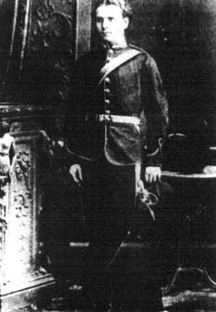

(102) Webb (1914), op cit, pp 281, and 296-298; K. Sinclair, ed. A Soldier's View of Empire: The Reminiscences of James Bodell, 1831-92 (London: The Bodley Head Ltd., 1982), pp 164-166; J Cowan, The New Zealand Wars: A History of the Maori Campaigns and the Pioneering Period: Vol II: The Hauhau Wars, 1864-1872 (Wellington, NZ: W A G Skinner, Government Printer, 1923), pp 148-154; and J Rorke, Policing Two Peoples: A History of Police in the Bay of Plenty 1867-1992 ([Tauranga, NZ]: Jinty Rorke and the New Zealand Police, 1993), pp 1-2.

(103) Captain C.A.F. Creagh was made Ensign on 8 September 1854 (without purchase), Lieutenant on 9 February 1855 (without purchase), and Captain 6 May 1863, 50th (Queens Own) Regiment.

(104) Lt. James ffranck Rolleston purchased his ensigncy on 17 June 1859.

(105) The Brisbane Courier, 13 October 1866, p.4; 15 October 1866, p.2; 16 October 1866, p.2; 17 October 1866, p.2; and 19 October 1866, p.3. Governor Bowen in a despatch dated Brisbane, 7 April 1867, informed Major-General Chute at Army Headquarters in Melbourne, of Queensland's intentions following receiving correspondence respecting the disposal of the remaining 5 Companies of the 50th Regiment still in New Zealand, from both Secretary of State for the Colonies, and Chute. "Having consulted my Responsible Advisors, I beg to inform you that there is accommodation in Queensland for one Company only - that now stationed at Brisbane; and that my Ministers think this to be a sufficient contingent for this Colony at the present time." GOV/G1: Governor's Office: Letterbook of Governor's Official Letters to Various Persons: Vol.1: Dec. 1859 - 12 Aug. 1871: Despatch No.7, dated Brisbane, 7 April 1867, pp.232-233. QSA.

(106) The Sydney Morning Herald, 23 October 1866, p.3. The remaining 5 Companies of the 50th Regiment in New Zealand continued manning redoubts in the Taranaki Province into 1867. On 3 June 1867, 2 of these Companies embarked for Sydney and on 11 July the remaining 3 Companies embarked for Adelaide. A.E. Fyler, The History of the 50th or (The Queen's Own) Regiment: From the earliest date to the year 1881 (London: Chapman and Hail, 1895), p 287.

(107) A regimental history actually states that 11 privates of the 50th Regiment were killed, and 2 officers and 18 privates were wounded during this engagement. Fyler (1895), op cit, pp 279-280.

(108) The Sydney Morning Herald, 23 October 1866, p 3.

(109) According to Hart's Army List for 1875, MacGregor purchased both his ensigncy (11 February 1858), and lieutenancy (12 March 1861), and had served in the campaigns on the West Coast of New Zealand from 31st December 1864 to 16th September 1866.

(110) The Brisbane Courier, 18 October 1867.

(111) The Brisbane Courier, 14 December 1866.

(112) The Brisbane Courier, 8 June 1868.

(113) The Brisbane Courier, 1 February 1868.

(114) According to Harts Army List for 1860, Eden gained his ensigncy on 22 February 1855, and lieutenancy on 26 February 1856, both without purchase. Eden later served in the West Coast campaign in New Zealand from 28 March 1865 to 16 September 1866.

(115) According to Harts Army List for 1875 he purchased his ensigncy on 15 November 1864 originally in the 36th Foot, before transferring into the 43rd Light Infantry, and finally the 50th Regiment on 10 November 1865.

(116) The Brisbane Courier, 5 and 10 August 1868.

(117) The Brisbane Courier, 31 January 1867, and 29 June 1867.

(118) The Brisbane Courier, 9 December 1867.

(119) The Brisbane Courier, 24 September 1867.

(120) The Brisbane Courier, 14 December 1867.

(121) The Brisbane Courier, 17 January 1868.

(122) The Brisbane Courier, 18 November 1868.

(123) Desertion rates were derived from the WO12 Quarterly Returns of these regiments, PRO; and Sexton (1985), op.cit..

(124) The Brisbane Courier, 20 December 1867; and 5 March 1869.

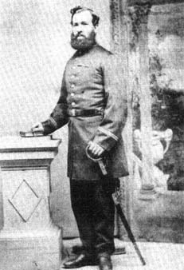

(125) The Brisbane Courier, 3 March 1869.

(126) A brief chronology of the history and events associated with St Helena Prison, 1866-1934:

```
   * 31 August 1866: St Helena opened as a Gaol.

   * 14 May 1867: St Helena proclaimed a Penal Establishment.

   * 8 July 1869: Select Committee appointed to inquire into, and report upon,
   the Expenditure on, and the Management of, the Penal Establishment at St
   Helena.

   * 15 November 1875: St Helena proclaimed a Gaol (no longer a Penal
Establishment).

   * 4 July 1879: St Helena is reproclaimed a Penal Establishment.

   * 1879: Petrie Terrace Goal is closed and all Male prisoners are removed to
   St Helena except for prisoners awaiting trial, debtors, criminal lunatics,
   and prisoners required as cooks and to keep the establishment clean and in
   order.

   * 17 February 1934: St Helena Penal Establishment is closed.
```

Guide to Prison Records which may be Useful to Genealogists: "Appendix 1: Brief Chronology of Penal Establishments in Queensland", pp 47-50. QSA.

(127) S Ba Pe, C Ham, & P McDougall, St Helena: Moreton Bay (Brisbane, October 1975), "Section 3.2: Superintendents".

(128) The prison hulk Proserpine was proclaimed a prison on 29 March 1864, so as to relieve overcrowding at the Brisbane Gaol. Prior to this, during 10 May 1863 - 29 April 1864, the Proserpine was utilised a reception place for refractory seamen, situated on the Brisbane River. The hulk Proserpine was not closed as a prison until 22 March 1871. Guide to Prison Records which may be Useful to Genealogists: "Appendix I: Brief Chronology of Penal Establishments in Queensland", p 47; and "Appendix 2: Geographical Listing of Penal Institutions in Queensland 1849 - 1988", p 52. QSA.

(129) Queensland Government Gazette, Vol III, No 17, 22 February 1862, p 108; Vol III, No 91, 11 October 1862, p 567; Vol IV, No 7, 24 January 1863, p 53; & Vol VI, No 56, 3 June 1865, p 461. Statistical Register of Queensland for the Year 1862 (Brisbane, Qld: W C Belbridge, Government Printer, 1863), p 27; Statistical Register of Queensland for the Year 1863 (Brisbane, Qld: W C Belbridge, Government Printer, 1864), pp 33 & 36; Statistical Register of Queensland for the Year 1864 (Brisbane, Qld: W C Belbridge, Government Printer, 1865), pp 26 & 33; & Statistical Register of Queensland for the Year 1866 (Brisbane, Qld: James C Beal, Government Printer, 1867), pp 43 & 44.

(130) COL/A87, In-Letter 116, dated 10 January 1867. QSA.

(131) Statistical Register of Queensland for the Year 1866 (Brisbane, Qld: James C. Be, al, Government Printer, 1867), p.44; Statistical Register of Queensland for the Year 1867 (Brisbane, Qld: James C. Beal, Government Printer, 1868), pp.43, 45 & 55; and Queensland Government Gazette, Vol.III, No.38, 18 May 1867, p.469.

(132) It appears a significant determinate in McDonald's decision was his wife's very poor health over the period 1880-81, during which time he took leave to visit her under care in Brisbane, as well as six weeks leave to take her to Victoria. Alice McDonald died in Brisbane on 8 September 1881, and was buried the next day at Toowong Cemetery. John McDonald died in Brisbane, Queensland, on 18 June 1895, and was buried the next day in the family plot at the Toowong Cemetery.

(133) Hart's Army List for 1860 states that Townley obtained his ensigncy in the Military Train (supply and logistics) on 30 April 1858, and purchased his lieutenancy on 17 December 1858. Townley was appointed captain in No.2 Battery, Queensland Volunteer Artillery on 13 February 1875; and later resigned his commission in this unit on 5 May 1877. For references to aspects of Townley's Queensland civil service, refer to: Queensland Government Gazette, Vol.XXXIII, No.62, 20 October 1883, p. 1080; Queensland Blue Book for the Year 1883 (Brisbane, Qld: Edmund Gregory, Acting Government Printer, 1884), p.27; and Pugh's Queensland Almanac: 1883, "Government Departments: Gaols, Etc.", p. 105.

(134) COL/A87, In-Letter 116, dated 10 January 1867. QSA.

(135) COL/A87, In-Letter 116, dated 10 January 1867. QSA.

(136) COL/A91, In-Letter 1254, dated 14 May 1867. QSA.

(137) COL/A99, In-Letter 3388, [dated November?] of 1867. QSA.

(138) Ibid..

(139) COL/A97, In-Letter 2832, dated 31 October 1867. QSA.

(140) COL/A100, In-Letter 64, dated December 1867. QSA. Superintendent John McDonald in May 1868, again brought to the attention of the Colonial Secretary and the "officer in charge of military detachment Brisbane", the "clandestine correspondence" between prisoners on St Helena and their friends in Brisbane through the aegis of the Military Guard serving at the Penal Establishment. Refer to, COL/A 105, In-Letter 1406, dated 11 May 1868. QSA.

(141) COL/A107, In-Letter 1856, "Military", dated 16 January 1868. QSA.

(142) COL/A101, In-Letter 337, dated 1 February 1868. QSA.

(143) COL/A102, In-Letter 610, dated 3 March 1868. QSA.

(144) COL/A107, In-Letter 1854, "Military", dated 17 June 1868, attached with In-Letter 1910 of 1868. QSA.

(145) COL/A107, In-Letter 1854, "Military", dated 17 June 1868, attached with In-Letter 1910 of 1868. QSA. Visiting Justice Barron's findings on 22 June 1868 did not find the soldiers' complaints were with foundation, though it is indicated that problems with rations, and other factors did exist. In respect to sentries, Barton stated: "Two sentries are required with the gangs employed clearing the scrub, another with the quarrying gang and two at the Goal. The Superintendent could not do with less without knocking off one of the gangs at work in the scrub. An addition of three to the [Military] Guard would render the duties comparatively light. At present the Warders who are fewer in number than the Guard, are on-duty five at a time during the day and two at night. There being an additional soldier on the island doing light duty, the duties of the day sentries are lightened as the soldier referred to supply five sentries once only out of the three reliefs. The Superintendent states that Captain Eden asked him whether he could manage with four sentries during the day until the Guard was relieved on account of one of the soldiers being disabled, he replied that he could but had to knock off one gang during the time there, were only four sentries, this is the only occasion he remembers Captain Eden speaking to him regarding the Sentries." COL/A107, In-Letter 1910, "Visiting Justice St Helena", dated 22 June 1868. QSA.

(146) COL/A107, In-Letter 1855, "Military", dated 16 June 1868 (and attached letter from Visiting Justice Barton, dated 6 June 1868). QSA.

(147) Superintendent John McDonald had one last opportunity to decry the conduct of the soldiers of the Military Guard when he was called in August 1869 to give evidence before the Select Committee inquiring into the expenditure and the management of St Helena. On 2 August McDonald provided the following testimony: -

"Do you find the constables superior to the military guard? Much superior in every sense. ...

In what does the superiority of the constable guard consist? it consists in the superior discipline of the police; they perform their duties much better than the military, guard; they keep a much better guard over the prisoners. There have been no complaints since the police have been on the island; before they came, not a week passed but a complaint of some kind or other was made against some of the military guard.

What was the nature of the complaints? Some of them were very serious. We have found them bringing letters from the prisoners' friends in their knapsacks, and they have come down to the island for duty drunk on more than one occasion. We have known them to steal everything they could lay their hands on, even to the prisoners' soap and tobacco out of the sheds. One of them has been known to carry away a Government wash-hand basin in his knapsack, at least it was taken out of his knapsack when he was leaving the island; in fact, they gave a great deal more trouble than the prisoners themselves. I found it was impossible to carry out strict discipline with the military on the island. Have you anything further to say on this subject?-Did you find that you had any control over the military guard? Not the slightest control.

Do you find you have sufficient control over the constable guard? Quite sufficient for all intents and purposes.

By Mr. Edmondstone: Has not the non-commissioned officer in charge of the military sufficient control over them to prevent these crimes? The military officer sent down in charge is very often a lance corporal, and he is only a private soldier acting as corporal. I know, from my own experience in the army, that a lance corporal is nobody amongst the men-he has no authority al all over them. It is impossible for such an officer to exercise any control over the men at such a distance from the head-quarters of the company."

"Report from the Select Committee on the Penal Establishment at St. Helena, together with the Proceedings of the Committee and Minutes of Evidence". Queensland Votes and Proceedings of the Legislative Assembly during the Session of 1869: Vol. I (Brisbane James C. Beal, Government Printer, 1869), p.876.

(148) Ibid., p.885.

(149) The colour scarlet has been a distinguishing feature of uniforms of the British Army since the 16th century. A. Makepeace-Warne, Brassey's Companion to the British Army (London: Brassey's, 1995), p.319.

(150) It had been earlier expected that the Brisbane 50th detachment was to depart for Sydney en route for England on 27 February, but this was delayed a fortnight. The Brisbane Courier, 27 February 1869, p 5.

(151) The Brisbane Courier, 11 March 1869, p 2. The regimental history of the 50th records: `The regiment remained in Australia till the 24th of March, 1869, when the head-quarters embarked at Sydney, on board the "Himalaya," which had previously taken up the Brisbane detachment. They arrived at Adelaide on the 29th, where they embarked the detachment under Colonel Hamley. The regiment disembarked at Devonport on the 14th of June, 1869.' A E Fyler, The History of the 50th or (The Queen's Own) Regiment: From the earliest date to the year 1881 (London: Chapman and Hall, 1895), p 288.

(152) The Brisbane Courier, 11 March 1869, p 2; and The Gympie Times, 18 March 1869. The Regimental History (1911) of the 18th Regiment makes no reference to a detachment of the 2/18th Regt ever landing in Brisbane for garrison duty during 1869-70. G le M Gretton, The Campaigns and History of the Royal Irish Regiment: From 1684 to 1902 (Edinburgh and London: William Blackwood and Sons, 1911).

(153) One example of an Imperial officer serving the colonial Queensland Government in the late 1860s into the 1870s, was Lieutenant George Hope Verney, 74th Regiment of Foot. This officer was appointed Aide-de-Camp to Queensland's 2nd Governor, A H Palmer, effective from 13 August 1868. On 20 January 1869, Lt Verney was appointed Captain in the Queensland Volunteer Rifle Brigade, and then Adjutant of the Queensland Volunteer Brigade, effective from 10 March 1869. Queensland Government Gazette, Vol IX, No 83, 17 August 1868, p 971; Vol X, No 6, 23 January 1869, p 83; & Vol X, No 25, 20 March 1869, p 365.

(154) The Brisbane Courier, 12 March 1869, p 2.

(155) The Argus, 9 January 1869, p.4; 11 January 1869, p.4; & 14 January 1869, p.5. Major-General Chute arrived in Sydney on 12 January, and thereafter departed for Auckland on 14 January. The Sydney Morning Herald, 13 January 1869, p.4; and 15 January 1869, p.4.

(156) "A.-No.9: Correspondence with the New Zealand Commissioners relative to the Employment of Imperial Troops: ...: No.2", Appendix to the Journals of the House of Representatives of New Zealand: Vol. 1. Legislative, Political, and Native: 1870 (Wellington: George Didsbury, Government Printer), pp.4-5 of A.-No.9.

(157) Chief Secretary's Office: GRG 24, Series 51, Special List No. 172. State Records of South Australia.

Hopkins-Weise, Jeff^Pratt, Rod

Copyright: COPYRIGHT 2001 Military Historical Society of Australia

http://www.mhsa.org.au/journal.html

### Source Citation

**Source Citation**

Hopkins-Weise, Jeff, and Rod Pratt. "The scarlet legacy: the British Army's forgotten presence in Moreton Bay, 1860-69." *Sabretache*, vol. 42, no. 2, June 2001, pp. 3+. *Gale Academic OneFile*, link.gale.com/apps/doc/A83447544/AONE?u=dixson&sid=bookmark-AONE&xid=123afc1b. Accessed 29 Oct. 2022.

**Gale Document Number:** GALE|A83447544